# Inkwell.ai — An AI-Powered Writing Marketplace Connecting Independent Writers and Magazine Publishers

End-of-Studies Project Report (Projet de Fin d’Études)

Oussama Bejaoui

Academic year 2025–2026

# End-of-Studies Project Report

## Inkwell.ai

### An AI-powered writing marketplace connecting independent writers and magazine publishers

Carried out by: **Oussama Bejaoui**

Project period: **1 February 2026 – 31 July 2026**

Academic year **2025–2026**

# Acknowledgements

# Abstract

Independent writers have tools to publish but few ways to be paid for quality, and magazines that want to commission them have no objective way to judge a writer before buying. This report presents **Inkwell.ai**, a two-sided web platform that addresses both sides. Writers draft in a rich-text editor beside an AI assistant grounded in their own published work and in reference documents they upload; it answers in a panel or writes directly into the document, cites its sources by page, and accepts spoken prompts. Every published article feeds an event-based analytics pipeline whose audience, content and quality signals, together with AI-generated portfolio insights, form an evaluation report that magazines use to decide. Magazines subscribe, receive monthly credits, preview an article for 10% of its price and buy the remainder for exclusive republication rights, every credit movement being recorded in a ledger whose invariants are tested after each operation.

The platform was built over nine two-week Scrum sprints grouped into four releases, with a Next.js 16 frontend, a NestJS 11 backend and worker, PostgreSQL 16 with pgvector, Redis and BullMQ, MinIO object storage and nginx, all containerised with Docker Compose, and with Groq and Gemini models orchestrated through the Vercel AI SDK. The backend suite counts 792 passing tests in 51 suites.

**Keywords:** writing marketplace, AI-assisted writing, retrieval-augmented generation, pgvector, analytics, article licensing, Scrum, NestJS, Next.js.

# Résumé

Les rédacteurs indépendants disposent d’outils pour publier, mais de peu de moyens d’être rémunérés pour la qualité de leur travail, et les magazines qui souhaitent leur confier des articles n’ont aucun moyen objectif d’évaluer un rédacteur avant d’acheter. Ce rapport présente **Inkwell.ai**, une plateforme web biface qui répond aux deux besoins. Les rédacteurs écrivent dans un éditeur de texte enrichi, aux côtés d’un assistant d’intelligence artificielle ancré dans leurs propres articles publiés et dans les documents de référence qu’ils déposent ; l’assistant répond dans un panneau ou écrit directement dans le document, cite ses sources à la page près et accepte des consignes dictées à la voix. Chaque article publié alimente une chaîne d’analyse fondée sur des événements, dont les indicateurs d’audience, de contenu et de qualité, complétés par une synthèse générée par l’IA, constituent un rapport d’évaluation sur lequel les magazines s’appuient pour décider. Les magazines s’abonnent, reçoivent des crédits mensuels, débloquent un aperçu pour 10 % du prix et achètent le reste pour obtenir des droits de republication exclusifs ; chaque mouvement de crédits est inscrit dans un grand livre dont les invariants sont vérifiés après chaque opération.

La plateforme a été réalisée en neuf sprints Scrum de deux semaines, regroupés en quatre releases, avec un frontend Next.js 16, un backend et un worker NestJS 11, PostgreSQL 16 avec pgvector, Redis et BullMQ, le stockage objet MinIO et nginx, le tout conteneurisé avec Docker Compose, les modèles Groq et Gemini étant orchestrés par le Vercel AI SDK. La suite de tests du backend compte 792 tests réussis répartis en 51 suites.

**Mots-clés :** place de marché d’écriture, rédaction assistée par l’IA, génération augmentée par la recherche, pgvector, analytique, licence d’articles, Scrum, NestJS, Next.js.

# List of acronyms

| Acronym | Meaning |
| --- | --- |
| AI | Artificial Intelligence |
| API | Application Programming Interface |
| CI/CD | Continuous Integration / Continuous Deployment |
| CRUD | Create, Read, Update, Delete |
| DTO | Data Transfer Object |
| FR / NFR | Functional / Non-Functional Requirement |
| GHCR | GitHub Container Registry |
| HNSW | Hierarchical Navigable Small World (approximate nearest-neighbour index) |
| JWT | JSON Web Token |
| LLM | Large Language Model |
| MoSCoW | Must, Should, Could, Won’t (prioritisation) |
| ORM | Object-Relational Mapping |
| PFE | Projet de Fin d’Études (end-of-studies project) |
| RAG | Retrieval-Augmented Generation |
| RRF | Reciprocal Rank Fusion |
| S3 | Simple Storage Service (object storage protocol) |
| SSE | Server-Sent Events |
| TLS | Transport Layer Security |
| TTS | Text-to-Speech |
| UML | Unified Modeling Language |
| US | User Story |

- General introduction
- Chapter 1 — Project context and methodology
  - Introduction
  - 1.1 Host organisation
  - 1.2 Project context
  - 1.3 Study of existing solutions
  - 1.4 Problem statement
  - 1.5 Proposed solution
  - 1.6 Development methodology
  - Conclusion
- Chapter 2 — Requirements analysis and specification
  - Introduction
  - 2.1 Identification of the actors
  - 2.2 Functional requirements
  - 2.3 Non-functional requirements
  - 2.4 Global use case diagram
  - 2.5 Global class diagram
  - 2.6 Product backlog
  - 2.7 Release plan
  - 2.8 Schedule
  - Conclusion
- Chapter 3 — Working environment and architecture
  - Introduction
  - 3.1 Working environment
  - 3.2 Technological choices
  - 3.3 Logical architecture
  - 3.4 Physical architecture
  - 3.5 Continuous integration and delivery
  - Conclusion
- Chapter 4 — Release 1: functional foundation
  - Introduction
  - 4.1 Sprint 1 — Schema, authentication and article core
  - 4.2 Sprint 2 — Editor, AI assistance and event capture
  - Conclusion
- Chapter 5 — Release 2: social interactions, analytics and AI
  - Introduction
  - 5.1 Sprint 3 — Social interactions, notifications and analytics
  - 5.2 Sprint 4 — Retrieval, portfolio insights and hybrid search
  - Conclusion
- Chapter 6 — Release 3: marketplace, testing and deployment
  - Introduction
  - 6.1 Sprint 5 — Marketplace, subscriptions, premium and moderation
  - 6.2 Sprint 6 — Tests, demonstration and deployment
  - Conclusion
- Chapter 7 — Release 4: social depth, the reworked assistant and documents
  - Introduction
  - 7.1 Sprint 7 — Comment likes, lists, block, save and share
  - 7.2 Sprint 8 — Live cards, the assistant that writes, and voice
  - 7.3 Sprint 9 — Document library and citations
  - Conclusion
- General conclusion and perspectives
  - Limitations
  - Perspectives
- References

# List of figures

- Figure 1.2 – Classic and agile approaches compared
- Figure 1.1 – The Scrum framework, as practised in this project
- Figure 2.1 – Global use case diagram
- Figure 2.2 – Class diagram: core domain
- Figure 2.3 – Class diagram: AI, marketplace and analytics
- Figure 2.4 – Gantt chart of the project
- Figure 3.1 – Logical frontend architecture
- Figure 3.2 – Logical backend architecture
- Figure 3.3 – Physical architecture
- Figure 3.4 – CI/CD pipeline
- Figure 4.1 – Use case diagram, Sprint 1
- Figure 4.2 – Class diagram, Sprint 1
- Figure 4.3 – Sequence diagram: sign in and silent refresh
- Figure 4.4 – The public feed, as seen by a visitor
- Figure 4.5 – Sign-in, with Google sign-in
- Figure 4.6 – Registering a personal account
- Figure 4.7 – Registering a magazine account
- Figure 4.8 – A free article, readable without an account
- Figure 4.9 – Profile settings
- Figure 4.10 – Use case diagram, Sprint 2
- Figure 4.11 – Class diagram, Sprint 2
- Figure 4.12 – Sequence diagram: inline AI action
- Figure 4.13 – The rich-text editor with the assistant panel
- Figure 4.14 – The publish dialog: placement, visibility, tags and excerpt
- Figure 4.15 – The AI assistant panel
- Figure 4.16 – An answer from the assistant
- Figure 4.17 – The inline actions on a selection
- Figure 4.18 – An inline suggestion, ready to replace the selection
- Figure 5.1 – Use case diagram, Sprint 3
- Figure 5.2 – Class diagram, Sprint 3
- Figure 5.3 – Sequence diagram: analytics aggregation
- Figure 5.4 – Sequence diagram: live notification delivery
- Figure 5.5 – The feed of a signed-in reader, with live card controls
- Figure 5.6 – Notifications, filtered and grouped by day
- Figure 5.7 – The writer’s dashboard
- Figure 5.8 – “My articles”: every article, sortable by performance
- Figure 5.9 – The writer’s analytics: views over the last 30 days
- Figure 5.10 – A writer’s public profile
- Figure 5.11 – A magazine browsing eligible writers
- Figure 5.12 – Use case diagram, Sprint 4
- Figure 5.13 – Class diagram, Sprint 4
- Figure 5.14 – Sequence diagram: the publishing pipeline
- Figure 5.15 – Sequence diagram: AI chat with retrieval
- Figure 5.16 – Sequence diagram: hybrid search with reciprocal rank fusion
- Figure 5.17 – Search results
- Figure 5.18 – A writer evaluation report with portfolio insights
- Figure 6.1 – Use case diagram, Sprint 5
- Figure 6.2 – Class diagram, Sprint 5
- Figure 6.3 – Sequence diagram: preview, purchase and publication
- Figure 6.4 – Activity diagram: the marketplace eligibility gate
- Figure 6.5 – Sequence diagram: reporting and moderation
- Figure 6.6 – Activity diagram: the article access decision
- Figure 6.7 – State diagram: the article lifecycle
- Figure 6.8 – A premium article behind the paywall
- Figure 6.9 – The plans: free and premium
- Figure 6.10 – A magazine’s subscription and credits
- Figure 6.11 – The marketplace, with preview and purchase prices
- Figure 6.12 – A listing before preview
- Figure 6.13 – Confirming a preview unlock: price and balance after
- Figure 6.14 – The magazine’s library: unpublished and published
- Figure 6.15 – Publishing a purchased article under the magazine’s masthead
- Figure 6.16 – A licensed article naming both the writer and the magazine
- Figure 6.17 – A magazine’s public profile and its published articles
- Figure 6.18 – A writer’s earnings, itemised by preview and purchase
- Figure 6.19 – A sold article, as its author sees it
- Figure 6.20 – Administration: manual eligibility grant
- Figure 6.21 – Administration: user management
- Figure 6.22 – Administration: the report queue
- Figure 6.23 – Test strategy
- Figure 7.1 – Use case diagram, Sprint 7
- Figure 7.2 – Class diagram, Sprint 7
- Figure 7.3 – The Saved shelf
- Figure 7.4 – Blocked accounts, in settings
- Figure 7.5 – The following feed
- Figure 7.6 – A follower list, searched
- Figure 7.7 – Use case diagram, Sprint 8
- Figure 7.8 – Sequence diagram: one assistant turn
- Figure 7.9 – Sequence diagram: writing into the document
- Figure 7.10 – Sequence diagram: the voice round trip
- Figure 7.11 – The Reposted tab of a profile
- Figure 7.12 – A write awaiting Keep or Discard
- Figure 7.13 – The live step on the collapsed panel
- Figure 7.14 – Recording a prompt
- Figure 7.15 – Use case diagram, Sprint 9
- Figure 7.16 – Class diagram, Sprint 9
- Figure 7.17 – Sequence diagram: document upload and ingestion
- Figure 7.18 – The document library, one document refused with its reason
- Figure 7.19 – Attaching a document from the Sources tab
- Figure 7.20 – A reply citing its source as [Title, p. N]

# List of tables

- Table 1.1 – Comparison of existing solutions
- Table 2.1 – Actors of the system
- Table 2.2 – Functional requirements of the visitor
- Table 2.3 – Functional requirements of the readers
- Table 2.4 – Functional requirements of the writers
- Table 2.5 – Functional requirements of the magazines
- Table 2.6 – Functional requirements of the administrator
- Table 2.7 – Cross-cutting functional requirements
- Table 2.8 – Non-functional requirements
- Table 2.9 – Product backlog by epic
- Table 2.10 – Release plan
- Table 3.1 – Software tools
- Table 3.2 – Frontend technologies
- Table 3.3 – Backend technologies
- Table 3.4 – AI models and their use
- Table 4.1 – Sprint 1 backlog
- Table 4.2 – Textual description of “Publish an article”
- Table 4.3 – Sprint 2 backlog
- Table 5.1 – Sprint 3 backlog
- Table 5.2 – Main metrics of the evaluation report
- Table 5.3 – Sprint 4 backlog
- Table 6.1 – Sprint 5 backlog
- Table 6.2 – Marketplace rules
- Table 6.3 – Sprint 6 backlog
- Table 6.4 – Test results
- Table 7.1 – Sprint 7 backlog
- Table 7.2 – Sprint 8 backlog
- Table 7.3 – Sprint 9 backlog

# General introduction

Writing has never been easier to publish and never harder to be paid for. Blogging platforms and newsletter services let anyone reach readers in minutes, and large language models now help with drafting, rephrasing and editing. Yet an independent writer who produces consistently good work still has few routes to income beyond advertising or reader subscriptions, and the publications that would happily pay for that work struggle to find it — and, once they find it, to judge it on anything firmer than a few samples and intuition.

This end-of-studies project starts from that double gap. On one side, writers need an assistant that helps them write *in their own voice*, not a generic text generator; on the other, magazines need objective signals — who reads a writer, how far, how often they come back — before they commit money. Between the two, a market is missing: a place where a magazine can browse, evaluate and license an existing article directly from its author, with clear terms and a trustworthy record of who paid what.

**Inkwell.ai** is the platform built to fill that gap. It combines three pillars:

1. **AI-collaborative writing** — an assistant integrated into the editor as chat, inline actions and voice input, grounded in the writer’s published corpus and in reference documents the writer uploads, able to write directly into the draft;
2. **decision-support analytics** — every published article generates audience, content and quality signals that feed dashboards for the writer and an evaluation report for magazines, completed by AI-generated portfolio insights;
3. **an article licensing marketplace** — magazines are a distinct account type that subscribes, receives monthly credits, previews an article for a tenth of its price and buys the rest for exclusive republication rights.

The work was carried out over six months, from February to July 2026, following the Scrum framework in nine fixed two-week sprints grouped into four releases. This report follows that structure:

- **Chapter 1** presents the context of the project, studies existing solutions, states the problem and justifies the choice of Scrum as the development method.
- **Chapter 2** analyses and specifies the requirements: actors, functional and non-functional requirements, the global use case and class diagrams, the product backlog and the release plan.
- **Chapter 3** describes the working environment, the technological choices and the logical and physical architecture of the system.
- **Chapters 4 to 7** present the four releases sprint by sprint — the sprint backlog, the analysis and design (use case, class and sequence diagrams) and the realisation — from the functional foundation to the marketplace, testing and deployment, and finally to the reworked assistant and the document library.

A general conclusion summarises the results and opens perspectives for the platform.

# Chapter 1 — Project context and methodology

## 1.2 Project context

The project was proposed as an end-of-studies engineering project with an ambitious, product-shaped scope: not a prototype of one feature, but a complete two-sided platform with real accounts, real data flows, an AI layer and money-like transactions. Three observations motivated it.

- **Generative AI has changed how text is produced**, but most writing assistants are generic: they write *for* the user rather than *like* the user, and they know nothing of what the writer has already published.
- **Engagement data is collected everywhere and used for very little.** Platforms measure views and reading time to rank content for readers, but none exposes those signals as evidence to a buyer evaluating a writer.
- **Content licensing between independent writers and publications is informal.** It happens by e-mail, on personal relationships, with no shared record of terms or payments.

## 1.3 Study of existing solutions

### 1.3.1 Publishing and newsletter platforms

**Medium** is an open publishing platform where readers subscribe to the platform and writers in its partner programme are paid according to member reading time. It offers good reading surfaces and audience statistics, but no AI assistance grounded in the writer’s corpus, and no way for a publication to license an article.

**Substack** lets writers run paid newsletters: readers subscribe to a writer directly. It has made independent writing a viable business for some, but its economic model is the reader subscription; there is no marketplace in which a publication buys an existing piece.

### 1.3.2 Freelance content marketplaces

Content marketplaces such as **Contently** or general freelance platforms connect brands with writers for *commissioned* work. Evaluation rests on portfolios, ratings and interviews; the work does not yet exist when it is bought, and the platform holds no engagement data about the writer’s published pieces.

### 1.3.3 AI writing assistants

Tools such as **Grammarly** or **Notion AI** assist with grammar, tone and generation inside a document. They are powerful editors, but they are not grounded in the writer’s own body of work, they do not cite the sources a passage came from, and they are disconnected from any publishing or licensing workflow.

### 1.3.4 Comparative synthesis

Table 1.1 compares these families of solutions with the criteria the project targets.

**Table 1.1 – Comparison of existing solutions**

| Criterion | Medium | Substack | Content marketplaces | AI writing assistants | **Inkwell.ai** |
| --- | --- | --- | --- | --- | --- |
| Publishing and public reading | ✓ | ✓ | — | — | ✓ |
| AI assistance in the editor | — | — | — | ✓ | ✓ |
| Assistant grounded in the writer’s own work | — | — | — | — | ✓ |
| Answers citing uploaded documents by page | — | — | — | partial | ✓ |
| Engagement analytics for the writer | ✓ | ✓ | — | — | ✓ |
| Analytics exposed to a buyer as evidence | — | — | — | — | ✓ |
| Licensing of existing articles to publications | — | — | — | — | ✓ |
| Traceable payments (ledger) | partial | ✓ | ✓ | — | ✓ |

## 1.4 Problem statement

The study shows that each existing family covers part of the need and that the parts do not meet. The problem can be stated on three levels:

- **Supply side.** Writers lack an assistant that helps them write better *in their own voice*, grounded in what they have already published and in the material they are working from, and they lack a direct path to be paid for quality.
- **Demand side.** Magazines lack objective, comparable signals about a writer’s audience, consistency and quality, and must evaluate by hand.
- **Market.** There is no self-service place where a publication can discover, evaluate, preview and license an existing article, with the money recorded in a way both parties can trust.

## 1.5 Proposed solution

Inkwell.ai answers these three levels with one platform:

- an **editor with an AI assistant** that retrieves passages from the writer’s own published articles and attached reference documents, decides per request whether to answer in a panel or write into the document, streams what it writes into a protected range the writer keeps or discards, cites passages by page, and accepts spoken prompts;
- an **analytics pipeline** that turns reading events into per-article and per-writer metrics, presented to the writer for self-improvement and to magazines as an evaluation report with AI portfolio insights;
- a **marketplace** gated by an eligibility threshold, where magazines with an active subscription preview an article for 10% of its price, buy the remaining 90% for exclusive rights, and publish it under their own masthead — every credit movement being written to a ledger inside one database transaction.

## 1.6 Development methodology

### 1.6.1 Sequential and agile approaches

A **sequential (waterfall) process** runs requirements, design, implementation, testing and delivery once each, in order; working software exists only at the end. An **agile process** builds the product in short iterations, each delivering a working increment that is reviewed before the next is planned. Figure 1.2 contrasts the two.

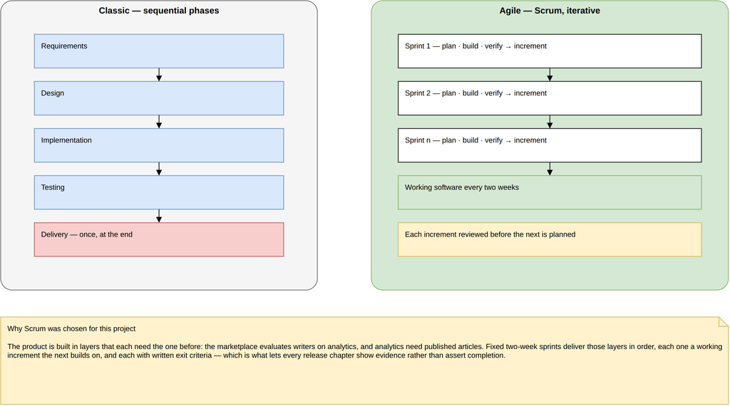

Figure 1.2 – Classic and agile approaches compared

### 1.6.2 Choice of Scrum

Inkwell.ai is built in layers that each depend on the previous one: the marketplace evaluates writers on analytics, analytics need published articles, and articles need accounts and an editor. An iterative method fits that layering: each sprint delivers a working layer that the next one builds on and that can be demonstrated on its own. Among agile frameworks, **Scrum** was chosen for its fixed-length sprints, its explicit artefacts — product backlog, sprint backlog, increment — and its events, which give an individual project the regular checkpoints a supervisor can follow.

### 1.6.3 Scrum as practised in this project

Figure 1.1 shows the framework as it was applied.

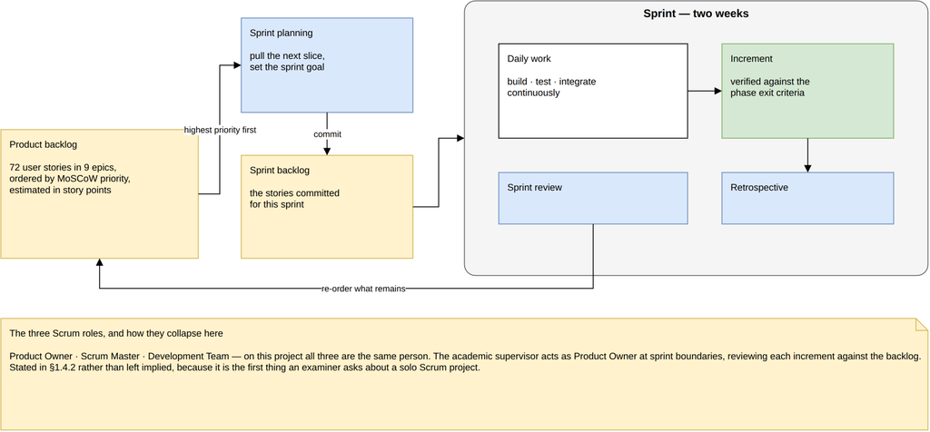

Figure 1.1 – The Scrum framework, as practised in this project

- **Roles.** The project is carried out by one person, who therefore holds the roles of Development Team and Scrum Master. The academic supervisor acts as Product Owner at sprint boundaries, reviewing each increment against the backlog.
- **Artefacts.** The product backlog holds 72 user stories in 9 epics, prioritised with MoSCoW and estimated in story points (Chapter 2). Each sprint has its own backlog and ends with a working increment.
- **Events.** Each two-week sprint starts with planning — pulling the highest-priority stories and setting a sprint goal — and ends with a review of the increment and a retrospective. Each phase of work carries written exit criteria, which is what lets every release chapter show evidence rather than assert completion.

### 1.6.4 Modelling language

Analysis and design use **UML 2**: use case diagrams for the functional scope of each sprint, class diagrams for the data model, sequence diagrams for the main interactions, and activity and state diagrams where a decision or a lifecycle is the subject. The diagrams are kept as text sources (PlantUML) or generated (draw.io) in the project repository, so they are versioned beside the code they describe.

## Conclusion

This chapter presented the context of the project, compared the existing solutions and showed that none combines AI-assisted writing grounded in the writer’s own work, buyer-facing analytics and a licensing market. It stated the resulting problem and the proposed solution, and justified the use of Scrum. The next chapter analyses and specifies the requirements of the platform.

# Chapter 2 — Requirements analysis and specification

## Introduction

This chapter specifies what the platform must do. It identifies the actors, states the functional requirements per actor and the non-functional requirements, presents the global use case diagram and the global class diagrams, and then organises the work as a product backlog of user stories distributed over a release plan and a schedule.

## 2.1 Identification of the actors

The platform has eight actors. They are not independent: they generalise one another, mirroring the three independent properties every account carries in the data model — its **account type** (personal or magazine), its **role** (reader, writer or administrator) and its **plan** (free or premium) — plus the writer’s marketplace eligibility. Table 2.1 lists them.

**Table 2.1 – Actors of the system**

| # | Actor | Data-model representation | Definition |
| --- | --- | --- | --- |
| A1 | Visitor | no account | Unauthenticated. Sees the public feed and free article bodies; cannot interact. |
| A2 | Free reader | personal account, free plan | Reads free public articles, interacts socially, has no AI allowance. |
| A3 | Premium reader | personal account, premium plan | Everything A2 has, plus premium articles and the daily AI allowance. |
| A4 | Writer | role writer | A2/A3 plus drafting, publishing and editing their own articles. |
| A5 | Eligible writer | marketplace-eligible writer | A4 plus the right to publish premium articles and to list on the marketplace. |
| A6 | Magazine (unsubscribed) | magazine account, no active subscription | Registered magazine stopped at the subscription wall. |
| A7 | Magazine (subscribed) | magazine account, active subscription | Browses writers, reads evaluation reports, spends credits to preview and purchase. |
| A8 | Administrator | role admin | Moderation queue, user management, manual eligibility grants. |

Three generalisations hold: the premium reader generalises the free reader, the eligible writer generalises the writer, and the subscribed magazine generalises the unsubscribed one. Role and plan are deliberately independent: a writer may stay on the free plan and write without AI assistance. The administrator role cannot be obtained through the interface; it is granted directly in the database.

## 2.2 Functional requirements

The functional requirements are stated per actor, each with a stable identifier, a MoSCoW priority and the sprint that delivers it. Identifiers are stable rather than sequential: a requirement added later keeps the next free number and is listed beside the feature it belongs to.

### 2.2.1 Visitor (A1)

**Table 2.2 – Functional requirements of the visitor**

| ID | Requirement | Priority | Sprint |
| --- | --- | --- | --- |
| FR-01 | Browse the public feed, paginated, with title, excerpt, thumbnail and tags | Must | 1 |
| FR-69 | Continue any article list as the reader scrolls, with a “Load more” control that remains available and a failed page that neither discards loaded rows nor retries itself | Must | 1 |
| FR-02 | Read the full body of a free public article without an account | Must | 1 |
| FR-03 | Be blocked from premium and marketplace articles, with an explicit prompt to sign up | Must | 1 |
| FR-71 | Not see a marketplace listing on the writer’s public profile at all — the exceptions being the article’s own author and an administrator | Must | 1 |
| FR-75 | Read a magazine’s published articles on its public profile, paginated, without an account | Must | 1 |
| FR-76 | See both the writer and the publishing magazine named on a licensed article, each linking to its own profile | Must | 1 |
| FR-77 | Preview a writer or magazine from any byline by hovering it — name, bio, counts and a follow control for a writer; logo, description and founding date for a magazine — without leaving the page | Should | 8 |
| FR-04 | Register as a personal account, or as a magazine account | Must | 1 |
| FR-05 | Authenticate by email/password or Google OAuth | Must | 1 |
| FR-06 | Search articles and writers, and browse by tag | Should | 4 |

Free public articles are deliberately readable without an account: gating them would contradict the public feed and its search-engine visibility.

### 2.2.2 Free and premium reader (A2, A3)

**Table 2.3 – Functional requirements of the readers**

| ID | Requirement | Priority | Sprint |
| --- | --- | --- | --- |
| FR-07 | Manage a profile — display name, bio, avatar upload | Must | 1 |
| FR-08 | Like an article, and un-like it | Must | 3 |
| FR-09 | Comment on an article, and reply to a comment (threaded) | Must | 3 |
| FR-10 | Delete one’s own comment | Must | 3 |
| FR-60 | Like a comment or a reply, and un-like it | Must | 7 |
| FR-66 | Like, repost and comment on an article from a feed card, and see whether one has already liked or reposted it | Must | 8 |
| FR-68 | See a feed card’s most recent comments from the last hour, up to three, without opening the article | Could | 8 |
| FR-11 | Repost an article | Could | 3 |
| FR-70 | Be refused when liking, commenting on or reposting a marketplace listing, while saving one stays available | Must | 3 |
| FR-67 | Read any account’s reposts from the Reposted tab on its profile, without an account | Should | 8 |
| FR-12 | Follow and unfollow a writer | Should | 3 |
| FR-61 | View any profile’s followers and following lists, and follow or unfollow from them | Must | 7 |
| FR-62 | Block an account, and review and lift one’s blocks from settings | Must | 7 |
| FR-63 | Save an article from the feed card or from the article page, and unsave it | Must | 7 |
| FR-64 | Review one’s own saved articles, from the sidebar or from the Saved tab on one’s own profile | Must | 7 |
| FR-65 | Share an article or a writer profile to X, Facebook or LinkedIn, or copy its link, without needing an account | Should | 7 |
| FR-13 | Receive notifications for follows, likes, comment likes, saves, comments and replies, delivered live | Must | 3 |
| FR-14 | List past notifications and mark them read | Must | 3 |
| FR-15 | Upgrade to premium, and downgrade (simulated payment) | Must | 5 |
| FR-16 | *(A3 only)* Read premium-visibility articles | Must | 5 |
| FR-17 | *(A3 only)* Consume a daily AI token allowance | Must | 2 |

### 2.2.3 Writer and eligible writer (A4, A5)

**Table 2.4 – Functional requirements of the writers**

[output not shown]

Voice in this product is the *voice prompt* of FR-82, which dictates a request to the assistant; dictating a whole article is outside the scope of the project.

### 2.2.4 Magazine (A6, A7)

**Table 2.5 – Functional requirements of the magazines**

| ID | Requirement | Priority | Sprint |
| --- | --- | --- | --- |
| FR-39 | Register with magazine fields — name, slug, logo, website, description | Must | 1 |
| FR-40 | *(A6)* Be stopped at a subscription wall before any marketplace surface | Must | 5 |
| FR-41 | Subscribe, receiving a monthly credit allowance (simulated payment) | Must | 5 |
| FR-42 | Top up credits outside the monthly grant | Should | 5 |
| FR-43 | See the credit balance, the renewal date and the transaction history | Must | 5 |
| FR-44 | Browse eligible writers, filtered by topic, searchable, with four sort orders | Must | 3 |
| FR-45 | Read a writer evaluation report — audience, content, quality panels | Must | 3 |
| FR-46 | Request AI Portfolio Insights for a writer, as an explicit action | Must | 4 |
| FR-47 | Browse a writer’s marketplace-listed articles with prices | Must | 5 |
| FR-48 | Unlock a preview for 10% of the price, and read the full article | Must | 5 |
| FR-49 | Purchase the remainder (90%) and gain republish rights | Must | 5 |
| FR-50 | See the curated library of fully purchased articles | Must | 5 |
| FR-72 | Be refused when previewing, buying, switching to public, or deleting an article another magazine has already purchased exclusively | Must | 5 |
| FR-73 | Publish an article it has purchased, under its own masthead — making it public and free, clearing the price, and recording the publisher | Must | 5 |
| FR-74 | See the library split into what has been published and what is still waiting, and act only on the second | Must | 5 |

Portfolio Insights generation is an explicit action rather than a side effect of opening a page, because each generation costs a model call.

### 2.2.5 Administrator (A8)

**Table 2.6 – Functional requirements of the administrator**

| ID | Requirement | Priority | Sprint |
| --- | --- | --- | --- |
| FR-51 | Review a queue of reports on articles, users and comments | Must | 5 |
| FR-52 | Dismiss a report, delete the reported article, or ban its author | Must | 5 |
| FR-53 | List and search users, filtered by role and by active/banned | Should | 5 |
| FR-54 | Edit a user’s plan (both directions), logged | Should | 5 |
| FR-55 | Grant marketplace eligibility manually, with an audit-log entry | Must | 5 |

Several refusals are enforced server-side, each pinned by a test: the administrator role cannot be assigned, an administrator’s role cannot be edited, nobody can edit their own role or plan, a banned account cannot be edited, and a magazine cannot be given a role.

### 2.2.6 Cross-cutting requirements

**Table 2.7 – Cross-cutting functional requirements**

| ID | Requirement | Priority | Sprint |
| --- | --- | --- | --- |
| FR-56 | Every article body access decision is taken server-side against the §7.4 matrix; locked content arrives as null | Must | 5 |
| FR-57 | Content is classified at publish time; a flag files a pending report but never blocks publication | Should | 5 |
| FR-58 | Any credit movement writes ledger rows inside one transaction, under a row lock | Must | 5 |
| FR-59 | Report an article, a user or a comment | Must | 5 |

## 2.3 Non-functional requirements

Each non-functional requirement is stated as a property together with the mechanism that provides it, so that it can be verified rather than asserted. Table 2.8 groups them by quality attribute.

**Table 2.8 – Non-functional requirements**

| ID | Requirement | Mechanism |
| --- | --- | --- |
| **Security** |  |  |
| NFR-01 | Passwords stored as bcrypt hashes, cost factor 12 | authentication module |
| NFR-02 | Access tokens expire after 15 minutes, refresh tokens after 7 days | signed JWTs; the refresh token is stateless, so its lifetime is the bound on its validity |
| NFR-03 | Every protected route passes one composed guard stack | a single `@Auth()` decorator composing JWT, role, plan, account-type, subscription and AI-quota guards |
| NFR-04 | Authorisation is decided server-side; the client is told the verdict | the article access matrix evaluated by the API; locked content arrives as `null` |
| NFR-05 | Per-address rate limits on every endpoint, tighter on credential routes | 60 requests/min globally, 10/min on sign-in, 5/min on registration |
| NFR-06 | Financial operations are idempotent under retry | a unique idempotency key on every ledger transaction |
| NFR-07 | Uploads are presigned, time-limited and never routed through the API | 10-minute presigned PUT; the public bucket grants object reads only |
| NFR-08 | Datastore ports bind to the loopback interface only | Compose port bindings on `127.0.0.1` |
| NFR-09 | A ban takes effect at the next authentication | soft-deletion checked on sign-in, refresh and Google sign-in |
| NFR-10 | No stored HTML is ever rendered as markup | no raw-HTML rendering anywhere in the frontend |
| **Performance** |  |  |
| NFR-11 | Semantic retrieval stays sub-linear as the corpus grows | HNSW index on the embedding column (m = 16, ef_construction = 64) |
| NFR-12 | Full-text search is index-backed with weighted ranking | generated `tsvector` column with weights A/B/C and a GIN index |
| NFR-13 | Prompt context is bounded | at most 5 retrieved passages, a memory block under 200 tokens, about 2,000 tokens in total |
| NFR-15 | Dashboard totals and rates read pre-aggregated rows | four rollup tables refreshed by the worker |
| NFR-16 | Analytics aggregation is incremental and idempotent | each run reads only the events since the last one |
| NFR-17 | Expensive AI output is cached and invalidated by what changes it | portfolio insights cached 24 h and dropped when the writer publishes |
| NFR-18 | Streaming responses are never buffered end to end | nginx `proxy_buffering off` and a 300 s read timeout on streaming routes |
| **Reliability** |  |  |
| NFR-19 | Every denormalised balance equals the sum of its ledger rows | three invariants asserted after every money-moving test |
| NFR-20 | Concurrent purchases cannot double-spend | `SELECT … FOR UPDATE` on the balance-owning row inside the transaction |
| NFR-21 | Schema changes are versioned and applied before the application starts | a one-shot migration service the API and worker depend on |
| NFR-23 | Failed background jobs retry with exponential back-off | three attempts per job |
| NFR-24 | An AI provider outage degrades AI only | a model chain falling back from Groq to Gemini; the rest of the product is unaffected |
| NFR-25 | Every service reports liveness and readiness | `GET /health` and `GET /ready` |
| **Scalability** |  |  |
| NFR-26 | The API holds no session state | identity carried by JWT claims |
| NFR-27 | Long-running work never runs in the request path | six BullMQ queues consumed by a separate worker process |
| NFR-28 | API and worker scale horizontally behind the proxy | stateless containers, one Compose service each |
| **Maintainability** |  |  |
| NFR-29 | Both code bases compile in strict mode with zero lint warnings | `tsc --noEmit`, `eslint --max-warnings=0` in continuous integration |
| NFR-30 | The API contract is generated from OpenAPI | client types generated from the backend’s OpenAPI document |
| NFR-31 | Business rules are tested, not asserted | 792 backend tests in 51 suites; 183 end-to-end tests in 25 files |
| NFR-32 | The build fails when schema and migrations disagree | a schema-drift check in continuous integration |
| NFR-33 | Errors are captured in every runtime without personal data | Sentry in API, worker, Next.js server and browser |
| **Usability** |  |  |
| NFR-34 | Two breakpoints are designed and implemented | 375 px and 1280–1440 px |
| NFR-35 | One design system, applied consistently | 39 design tokens and 87 components in Figma |
| NFR-36 | A complete dark mode | theme switch across every screen |
| NFR-37 | Lighthouse score above 90 and no critical accessibility violation on article pages | planned — see the general conclusion |

## 2.4 Global use case diagram

Figure 2.1 gives the global use case diagram. It is deliberately coarse: each use case stands for a family of interactions refined in the per-sprint diagrams of Chapters 4 to 7. Every authenticated use case includes *Sign in*; *Sign in with Google* extends it; listing on the marketplace extends publishing; unlocking a preview extends acquiring an article; grounding answers in uploaded documents extends the use of the assistant, which always includes retrieval from the writer’s own corpus.

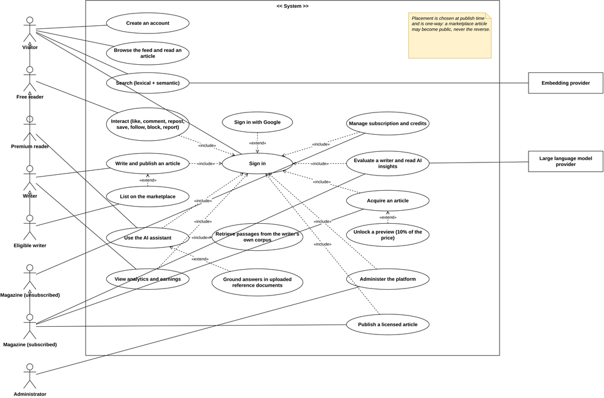

Figure 2.1 – Global use case diagram

## 2.5 Global class diagram

The data model counts thirty persisted tables. Drawn in a single diagram they form an unreadable strip, because the `User` class is related to most of the others, so the global class diagram is split by domain into two figures. Attributes are shown with domain types (`Json`, `Vector`, `Timestamp`); audit columns are omitted, and no methods are shown because the model is relational and its behaviour lives in the service layer.

**Core domain.** Figure 2.2 shows accounts, articles and their social layer: the `User` and its optional `MagazineProfile`, the `Article` with its placement, visibility and price, tags, threaded comments, likes, comment likes, reposts, saves, follows, blocks, notifications and reports. `Article.publisherId` names the magazine that published a licensed article and is empty for every other article.

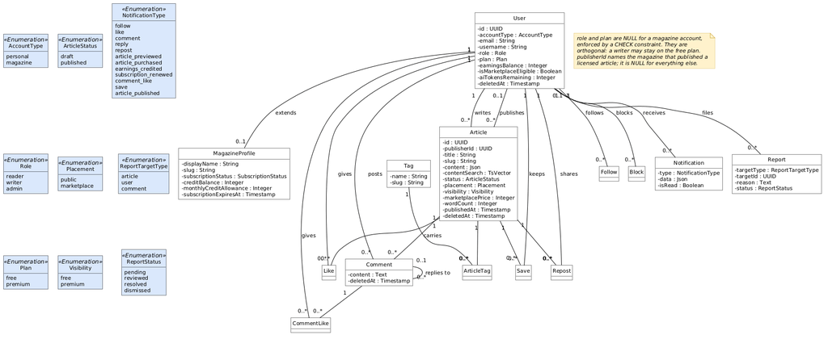

Figure 2.2 – Class diagram: core domain

**AI, marketplace and analytics.** Figure 2.3 shows the remaining sixteen tables: the article chunks embedded for retrieval, the writer memory, the cached portfolio insights and the AI interaction log; the private document library with its chunks and article attachments; purchases, ledger transactions, magazine subscriptions and the eligibility audit log; and the raw analytics events with the four metric rollups.

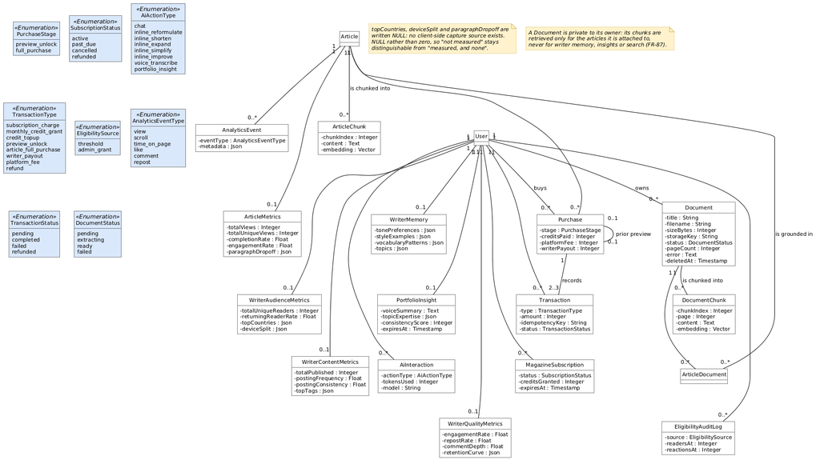

Figure 2.3 – Class diagram: AI, marketplace and analytics

## 2.6 Product backlog

**Table 2.9 – Product backlog by epic**

| Epic | Stories | Points |
| --- | --- | --- |
| E1 — Accounts and authentication | 5 | 17 |
| E2 — Writing and publishing | 8 | 30 |
| E3 — AI assistance | 6 | 38 |
| E4 — Discovery and search | 4 | 18 |
| E5 — Social interactions and notifications | 20 | 82 |
| E6 — Analytics | 4 | 32 |
| E7 — Marketplace and subscriptions | 12 | 63 |
| E8 — Moderation and administration | 6 | 24 |
| E9 — Quality and operations (technical stories) | 7 | 41 |
| **Total** | **72** | **345** |

**Table 2.9 (continued) – The product backlog, by epic**

**E1 — Accounts and authentication**

| ID | User story | Actor | Priority | Points | Sprint |
| --- | --- | --- | --- | --- | --- |
| US-01 | Register with an email and a password so that I can have an identity on the platform | A1 | Must | 3 | 1 |
| US-02 | Sign in with Google so that I do not manage another password | A1 | Should | 3 | 1 |
| US-03 | Register as a magazine with my branding so that writers recognise my publication | A1 | Must | 5 | 1 |
| US-04 | Stay signed in across a long writing session so that I do not lose a draft | A4 | Must | 3 | 1 |
| US-05 | Edit my profile and avatar so that my public page represents me | A2 | Should | 3 | 1 |

**E2 — Writing and publishing**

| ID | User story | Actor | Priority | Points | Sprint |
| --- | --- | --- | --- | --- | --- |
| US-06 | Write in a rich editor so that structure and emphasis survive publication | A4 | Must | 8 | 2 |
| US-07 | Have my draft saved as I type so that I never lose work | A4 | Must | 3 | 2 |
| US-08 | Paste or drag an image into the article so that illustrating is not a detour | A4 | Must | 5 | 2 |
| US-09 | Set a cover image so that my article looks deliberate in the feed | A4 | Should | 3 | 2 |
| US-10 | Tag an article so that readers find it by topic | A4 | Should | 2 | 1 |
| US-11 | Choose at publish time whether an article is public or for sale | A4 | Must | 5 | 1 |
| US-12 | Restrict an article to premium readers so that my best work is worth a subscription | A5 | Should | 3 | 5 |
| US-13 | See word count and reading time so that I can judge length as I write | A4 | Could | 1 | 2 |

**E3 — AI assistance**

| ID | User story | Actor | Priority | Points | Sprint |
| --- | --- | --- | --- | --- | --- |
| US-14 | Ask an assistant that has read my published work so that suggestions sound like me | A4 | Must | 13 | 2, 4 |
| US-15 | Reformulate, shorten, expand, simplify or improve a selection so that editing is one click | A4 | Must | 8 | 2 |
| US-16 | Insert an answer into my document so that I do not copy by hand | A4 | Must | 2 | 2 |
| US-17 | See which of my passages the assistant used so that I can trust the answer | A4 | Should | 5 | 4 |
| US-18 | See my remaining allowance so that I can pace my usage | A3 | Must | 2 | 2 |
| US-19 | Have my voice profile extracted from my corpus so that the assistant stays consistent when retrieval finds nothing | A4 | Should | 8 | 4 |

**E4 — Discovery and search**

| ID | User story | Actor | Priority | Points | Sprint |
| --- | --- | --- | --- | --- | --- |
| US-20 | Search by keyword so that I find an article I half-remember | A1 | Must | 5 | 4 |
| US-21 | Find articles that match my meaning even when they share none of my words | A1 | Must | 8 | 4 |
| US-22 | Browse by tag so that I can follow a topic | A1 | Should | 2 | 4 |
| US-23 | Find writers, not only articles, so that I can follow a person | A1 | Should | 3 | 4 |

**E5 — Social interactions and notifications**

| ID | User story | Actor | Priority | Points | Sprint |
| --- | --- | --- | --- | --- | --- |
| US-24 | Like an article so that I can signal quality | A2 | Must | 2 | 3 |
| US-25 | Comment and reply in a thread so that discussion has structure | A2 | Must | 5 | 3 |
| US-26 | Follow a writer so that I keep up with them | A2 | Should | 3 | 3 |
| US-27 | Repost an article so that my followers see it | A2 | Could | 2 | 3 |
| US-59 | React to an article from the feed so that I can engage without losing my place | A2 | Must | 5 | 8 |
| US-60 | See what an account has reposted so that I can judge what they rate | A2 | Should | 3 | 8 |
| US-61 | Reply in the moment from the feed so that a fresh conversation is easy to join | A2 | Could | 3 | 8 |
| US-62 | Keep reading as I scroll so that a list does not end at an arbitrary point I have to click past | A1 | Must | 5 | 8 |
| US-65 | See who a writer or magazine is from where their name appears so that I can decide to follow without leaving the feed | A1 | Should | 3 | 8 |
| US-66 | Tell the assistant what to write and watch it appear in my draft, then keep or discard it, so that generation happens where I write rather than in a chat I copy from | A4 | Must | 8 | 8 |
| US-67 | See what the assistant is doing while it works — and minimize it without losing sight of that — so that a slow step is not a frozen screen | A4 | Should | 3 | 8 |
| US-68 | Say my request instead of typing it so that I can brief the assistant while my hands are busy or my thoughts are faster than my typing | A4 | Should | 5 | 8 |
| US-69 | Hear the assistant’s recap read out so that I can keep my eyes on the draft — and mute it when I would rather not | A4 | Could | 3 | 8 |
| US-70 | Upload the documents I am working from so that the assistant can use their facts without my retyping them | A4 | Must | 8 | 9 |
| US-71 | Choose which documents apply to an article so that a piece on tides is not fed my notes on fermentation | A4 | Must | 3 | 9 |
| US-72 | See which document and page a claim came from so that I can check it before it goes out under my name | A4 | Should | 5 | 9 |
| US-57 | Save an article to come back to it later, without anyone else seeing what I keep | A2 | Must | 5 | 7 |
| US-58 | Pass an article on to people outside the platform so that they can read it without signing up | A1 | Should | 3 | 7 |
| US-28 | Be told the moment someone reacts to my work, without reloading | A4 | Must | 5 | 3 |
| US-29 | Review notifications I missed so that nothing is lost between sessions | A2 | Must | 3 | 3 |

**E6 — Analytics**

| ID | User story | Actor | Priority | Points | Sprint |
| --- | --- | --- | --- | --- | --- |
| US-30 | See how many people read an article and how far they got so that I can write better | A4 | Must | 8 | 3 |
| US-31 | Rank my articles by performance so that I learn what works | A4 | Should | 3 | 3 |
| US-32 | Evaluate a writer on audience, content and quality so that I can commission with evidence | A7 | Must | 13 | 3 |
| US-33 | Read an AI assessment of a writer’s voice and range so that I can shortlist quickly | A7 | Must | 8 | 4 |

**E7 — Marketplace and subscriptions**

| ID | User story | Actor | Priority | Points | Sprint |
| --- | --- | --- | --- | --- | --- |
| US-34 | Upgrade to premium so that I can read everything and use the assistant | A2 | Must | 5 | 5 |
| US-35 | Subscribe as a magazine so that I can access the marketplace | A6 | Must | 8 | 5 |
| US-36 | Receive a monthly credit budget so that spending is predictable | A7 | Must | 5 | 5 |
| US-37 | Top up credits so that a good month is not capped | A7 | Should | 3 | 5 |
| US-38 | Pay 10% to read an article in full so that I can judge before buying | A7 | Must | 8 | 5 |
| US-39 | Pay the remainder to acquire republish rights so that I can publish it | A7 | Must | 8 | 5 |
| US-40 | Keep purchased articles in a library so that my acquisitions are in one place | A7 | Must | 3 | 5 |
| US-63 | Publish an article I have bought when I am ready, rather than the purchase publishing it for me, so that my masthead stays mine to decide | A7 | Must | 5 | 5 |
| US-64 | Have the articles I publish appear on my public profile under my masthead so that licensing buys me a shelf and not just a file | A7 | Must | 5 | 5 |
| US-41 | List an article for sale at my own price so that I am paid for exclusivity | A5 | Must | 5 | 5 |
| US-42 | See my earnings itemised by preview and purchase so that I trust the accounting | A4 | Must | 5 | 5 |
| US-43 | See how far I am from eligibility so that the gate feels reachable | A4 | Should | 3 | 5 |

**E8 — Moderation and administration**

| ID | User story | Actor | Priority | Points | Sprint |
| --- | --- | --- | --- | --- | --- |
| US-44 | Report content so that abuse has a channel | A2 | Must | 3 | 5 |
| US-56 | Block an account so that I stop seeing someone without having to explain myself | A2 | Must | 5 | 7 |
| US-45 | Work a queue of reports so that moderation is systematic | A8 | Must | 5 | 5 |
| US-46 | Remove an article or ban an author so that decisions are enforceable | A8 | Must | 3 | 5 |
| US-47 | Grant eligibility manually so that a promising writer is not held back by a counter | A8 | Must | 3 | 5 |
| US-48 | Search and filter users so that I can act on the right account | A8 | Should | 5 | 5 |

**E9 — Quality and operations (technical stories)**

| ID | User story | Actor | Priority | Points | Sprint |
| --- | --- | --- | --- | --- | --- |
| US-49 | Prove that every balance equals its ledger sum, after every money-moving operation | — | Must | 8 | 1 |
| US-50 | Bring the whole stack up with one command, reproducibly | — | Must | 8 | 1 |
| US-51 | Fail the build on a lint error, a type error, a failing test or schema drift | — | Must | 5 | 1 |
| US-52 | Apply migrations automatically before the application starts | — | Must | 5 | 6 |
| US-53 | Seed a believable corpus so that the product can be demonstrated cold | — | Must | 5 | 6 |
| US-54 | Lower the eligibility thresholds under a flag so that the gate can be crossed live | — | Must | 2 | 6 |
| US-55 | Serve the product at a public URL over TLS | — | Must | 8 | 6 |

## 2.7 Release plan

The stories are delivered in four releases of two or three sprints each, every sprint lasting two weeks. Table 2.10 gives the plan; the foundation week and the three-sprint design track are not sprints, because they deliver no user-facing increment, and are presented with the working environment in Chapter 3.

**Table 2.10 – Release plan**

| Release | Chapter | Sprint | Dates | Goal |
| --- | --- | --- | --- | --- |
| **R1 — Functional foundation** | 4 | Sprint 1 | 09/02 – 20/02 | Schema, authentication, article core, ledger invariant harness |
|  |  | Sprint 2 | 06/04 – 17/04 | Editor, AI chat and inline actions, analytics event capture |
| **R2 — Social, analytics and AI** | 5 | Sprint 3 | 20/04 – 01/05 | Social interactions, notifications, aggregation, dashboards |
|  |  | Sprint 4 | 04/05 – 15/05 | Retrieval-augmented generation, portfolio insights, hybrid search, writer memory |
| **R3 — Marketplace, testing and deployment** | 6 | Sprint 5 | 18/05 – 29/05 | Marketplace, subscriptions, premium, moderation, administration |
|  |  | Sprint 6 | 01/06 – 12/06 | Tests, demo mode, deployment, CI/CD |
| **R4 — Social depth, assistant and documents** | 7 | Sprint 7 | 15/06 – 26/06 | Comment likes, follower lists, block, save, share |
|  |  | Sprint 8 | 29/06 – 10/07 | Live card controls, reposts tab, byline preview, assistant writing into the document, voice |
|  |  | Sprint 9 | 13/07 – 24/07 | Document library, ingestion, attachment, citations |

## 2.8 Schedule

Figure 2.4 places the work on the project window, from 2 February to 31 July 2026: the foundation week and Sprint 1, the design track, Sprints 2 to 9 in four releases, and the writing of this report alongside the last sprints.

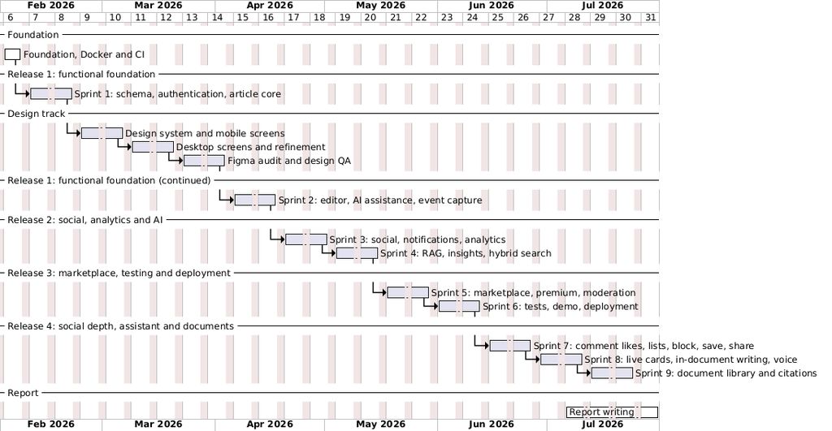

Figure 2.4 – Gantt chart of the project

## Conclusion

This chapter identified the eight actors of the platform, specified its functional and non-functional requirements, presented the global use case and class diagrams, and organised the work into a backlog of 72 user stories delivered by nine sprints in four releases. The next chapter describes the environment in which the work was done and the architecture of the system.

# Chapter 3 — Working environment and architecture

## 3.1 Working environment

### 3.1.2 Software environment

**Table 3.1 – Software tools**

| Tool | Use |
| --- | --- |
| JetBrains IDE | code editor |
| Git and GitHub | version control, pull requests, continuous integration (GitHub Actions) and container registry (GHCR) |
| Docker and Docker Compose | containers for every service, in development and in production |
| Figma | design system and screen design |
| PlantUML and draw.io | UML and architecture diagrams, kept as versioned sources |
| Swagger UI | exploring the REST API through the OpenAPI documentation the backend generates |
| Playwright | end-to-end tests and the capture of this report’s screenshots |

### 3.1.3 Foundation and design track

Two blocks of work preceded the feature sprints and are presented here rather than as sprints, because neither delivers a user-facing increment.

- **Foundation (one week).** The three repositories, their Docker images, the Compose stack, the reverse proxy and the continuous-integration pipeline were set up first, so that every later sprint started from a stack that builds, tests and runs with one command.
- **Design track (three sprints).** The user interface was designed in Figma before the editor and the social features were built: a design system of **39 tokens and 87 components**, then the full screen set at two widths — **375 px for mobile and 1280–1440 px for desktop**, 58 screens — then an audit of the screens against the specification. The release chapters implement these designs.

### 3.1.4 Repository organisation

The source code lives in four Git repositories. `docker.inkwell.ai` is the superproject: it holds the Compose files, the nginx configuration, the deployment workflow and the developer Makefile, and it carries the three others as **Git submodules** — `backend.inkwell.ai`, `frontend.inkwell.ai`, and `spec.inkwell.ai`, which holds the specifications, the diagrams and this report’s figures. A commit of the superproject therefore identifies one exact, deployable revision of the whole system.

## 3.2 Technological choices

### 3.2.1 Frontend

**Table 3.2 – Frontend technologies**

| Technology | Role | Why it was chosen |
| --- | --- | --- |
| **Next.js 16** (App Router) with **React 19** | web framework | server rendering for public articles and search engines, file-system routing, a request proxy for route protection |
| **TypeScript** (strict) | language | one typed language across frontend and backend |
| **Tailwind CSS 4** and accessible headless primitives | styling and components | implements the Figma design tokens directly; accessible dialogs, menus and tabs |
| **TipTap 3** | rich-text editor | ProseMirror-based, stores the document as JSON, extensible with the AI write range and inline actions |
| **TanStack Query 5** and **Zustand 5** | server state and client state | caching, optimistic updates and invalidation for API data; small stores for UI state |
| **Vercel AI SDK** (React bindings) | assistant client | consumes the typed UI-message stream of the assistant turn |
| **Axios** | HTTP client | interceptors implement the silent token refresh |

### 3.2.2 Backend

**Table 3.3 – Backend technologies**

| Technology | Role | Why it was chosen |
| --- | --- | --- |
| **NestJS 11** | API and worker framework | modular structure, dependency injection, guards and interceptors, OpenAPI generation |
| **Drizzle ORM** | data access and migrations | type-safe SQL close to PostgreSQL, explicit migrations, no hidden queries |
| **PostgreSQL 16 + pgvector** | single data store | relational data, full-text search (`tsvector`) and vector search (HNSW) in one database and one transaction |
| **Redis 7 + BullMQ** | queues and scheduled jobs | retries with back-off, repeatable jobs, a separate worker process |
| **MinIO** | object storage (S3 API) | images and private documents, uploaded by the browser through presigned URLs |
| **Vercel AI SDK** | AI orchestration | one interface over several providers, streaming, tool calls and typed UI streams |
| **Passport (JWT, Google OAuth 2.0)** and **bcrypt** | authentication | standard strategies; password hashing with cost factor 12 |

### 3.2.3 Artificial-intelligence services

**Table 3.4 – AI models and their use**

| Use | Provider and model |
| --- | --- |
| Chat, writing, inline actions, portfolio insights, writer memory | Groq — `gpt-oss-120b`, falling back to `gpt-oss-20b`, then Google `gemini-3.5-flash` |
| Embeddings (articles, documents, queries) | Google `gemini-embedding-001`, 1,536 dimensions |
| Speech-to-text (voice prompt) | Groq — `whisper-large-v3-turbo` |
| Text-to-speech (replies read aloud) | Google `gemini-2.5-flash-preview-tts` |
| Content moderation at publish time | Groq classifier model |

The chain of chat models is what makes a provider outage degrade the assistant only: the first chunk of a response is pulled before anything is sent to the browser, so a refusal from one model can still be answered by the next.

### 3.2.4 Infrastructure and quality

**Docker Compose** runs eight services — nginx, web, api, worker, a one-shot migration service, PostgreSQL, Redis and MinIO. **nginx** terminates TLS and routes traffic. **GitHub Actions** runs the quality gates and builds the images; **GHCR** stores them. **Jest** tests the backend against a real PostgreSQL database, **Playwright** drives a real browser end to end, and **Sentry** captures errors in the four runtimes.

## 3.3 Logical architecture

### 3.3.1 Frontend

Figure 3.1 shows the logical architecture of the frontend. The **routes** (28 pages) compose **feature modules** (18, among them the editor, the assistant, documents, saves, reposts, the marketplace and the evaluation report). A **state and data** layer holds the query cache, the client stores, the HTTP interceptors that refresh an expired access token and retry the request, and the analytics tracker. A **request proxy** protects private routes before a page renders. Two channels bypass the REST API: an **SSE client** for live notifications, and **direct uploads** from the browser to object storage through presigned URLs.

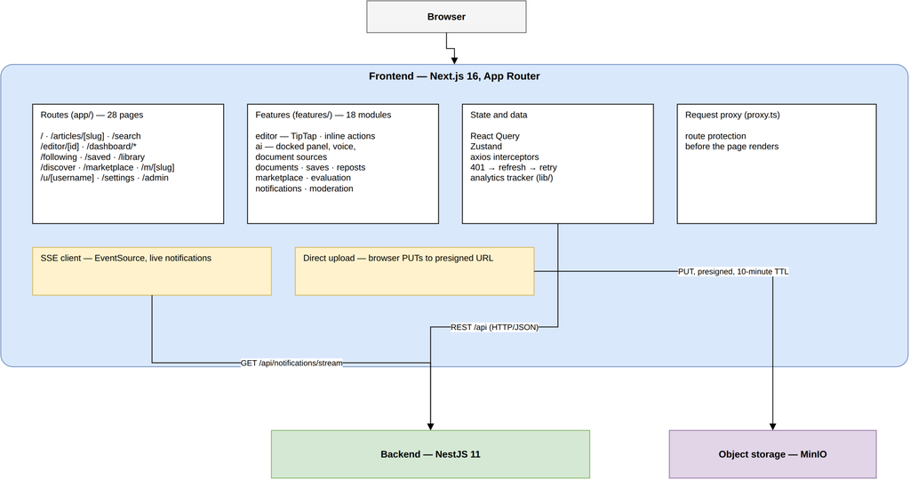

Figure 3.1 – Logical frontend architecture

### 3.3.2 Backend

Figure 3.2 shows the backend. The **API** is a modular NestJS application: a global rate-limiting guard runs on every route, then the guards composed once by the `@Auth()` decorator — authentication, role, plan, account type, subscription and AI quota. The feature modules cover authentication and users, articles, social interactions, AI, analytics, the marketplace, search and discovery, moderation and uploads, and documents. The **worker** runs from the same image with a second entry point and consumes six queues: `embeddings` (chunking and embedding articles, extracting writer memory), `analytics` (article and writer rollups), `marketplace` (eligibility and subscription renewal), `ai-tokens` (the nightly allowance reset), `documents` (extracting, chunking and embedding uploaded documents) and `ai-models` (a daily check that every model still answers).

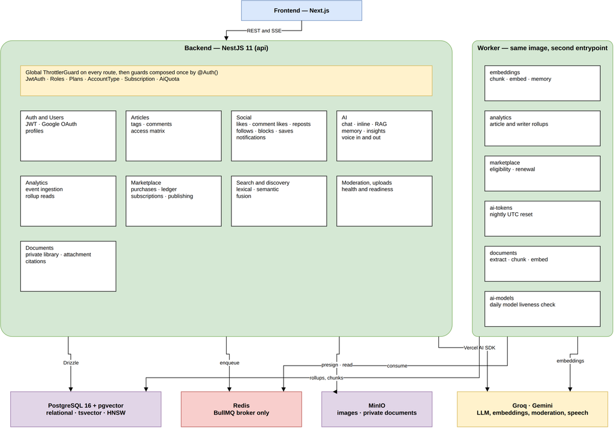

Figure 3.2 – Logical backend architecture

## 3.4 Physical architecture

Figure 3.3 shows the deployment. All eight services run under Docker Compose on one host. **nginx is the only service published**, on ports 80 and 443: it terminates TLS, proxies `/` to the Next.js server and `/api` to the NestJS API, keeps server-sent events unbuffered, and proxies the public image bucket at `/storage`. Private documents are never served through that path; they are read through the API, which checks ownership. The datastores are reachable only from inside the Compose network.

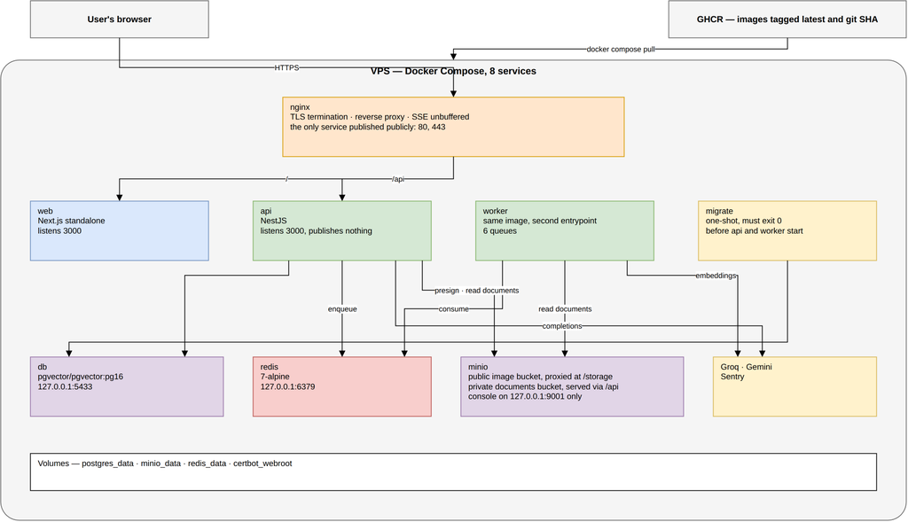

Figure 3.3 – Physical architecture

## 3.5 Continuous integration and delivery

Figure 3.4 shows the pipeline. A push to `main` on either application repository runs the quality gates — install, lint with zero warnings, type-check, the 792 backend tests, a schema-drift check — then builds a multi-stage image and pushes it to GHCR, tagged both `latest` and with the commit hash. A repository dispatch then triggers the deployment workflow of the superproject, which pulls the images on the server, runs the migrations (which must succeed before the API and worker start), restarts the services, verifies the health and readiness endpoints and reloads nginx.

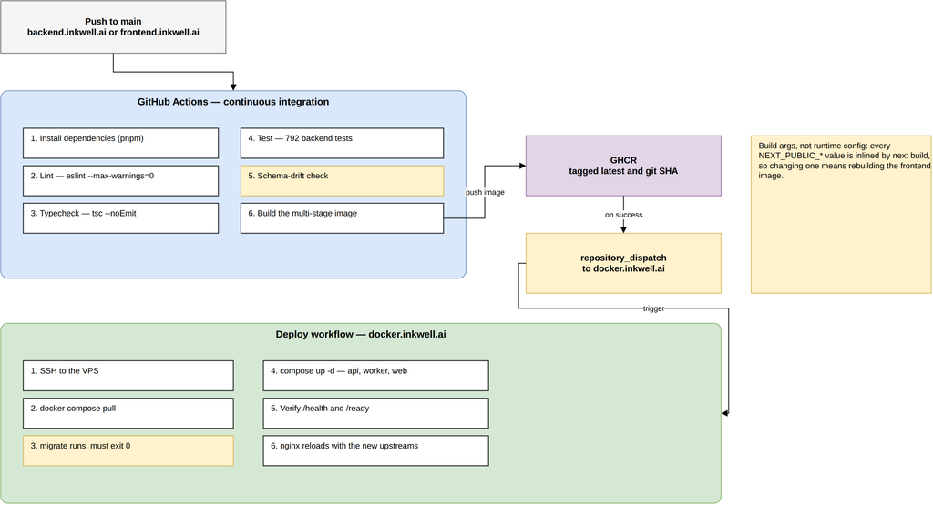

Figure 3.4 – CI/CD pipeline

## Conclusion

This chapter presented the working environment, justified the technological choices and described the logical and physical architecture of Inkwell.ai and its delivery pipeline. The following chapters present the four releases, starting with the functional foundation.

# Chapter 4 — Release 1: functional foundation

## Introduction

The first release lays the foundation every later feature depends on. Sprint 1 delivers the data model, authentication and the core of article management; Sprint 2 delivers the rich-text editor, the first version of the AI assistant and the capture of reading events that the analytics of Release 2 will aggregate. For each sprint this chapter gives the sprint backlog, the analysis and design, and the realisation.

## 4.1 Sprint 1 — Schema, authentication and article core

### 4.1.1 Sprint goal and backlog

**Goal:** a visitor can register and sign in, by password or with Google; a writer can create, edit, publish and delete articles, choosing their placement and visibility; a visitor can browse the public feed and read free articles. The sprint also establishes the ledger invariant harness that every later money-moving feature is tested against.

**Table 4.1 – Sprint 1 backlog**

| ID | User story | Priority | Points |
| --- | --- | --- | --- |
| US-01 | Register with an email and a password so that I can have an identity on the platform | Must | 3 |
| US-02 | Sign in with Google so that I do not manage another password | Should | 3 |
| US-03 | Register as a magazine with my branding so that writers recognise my publication | Must | 5 |
| US-04 | Stay signed in across a long writing session so that I do not lose a draft | Must | 3 |
| US-05 | Edit my profile and avatar so that my public page represents me | Should | 3 |
| US-10 | Tag an article so that readers find it by topic | Should | 2 |
| US-11 | Choose at publish time whether an article is public or for sale | Must | 5 |
| US-49 | Prove that every balance equals its ledger sum, after every money-moving operation | Must | 8 |
| US-50 | Bring the whole stack up with one command, reproducibly | Must | 8 |
| US-51 | Fail the build on a lint error, a type error, a failing test or schema drift | Must | 5 |
|  | **10 stories** |  | **45** |

### 4.1.2 Analysis

**Use case diagram.** Figure 4.1 refines the global diagram for Sprint 1. Registering specialises into registering as a reader or as a magazine; managing one’s own articles specialises into creating a draft, editing, publishing and deleting; publishing includes choosing a placement and a visibility.

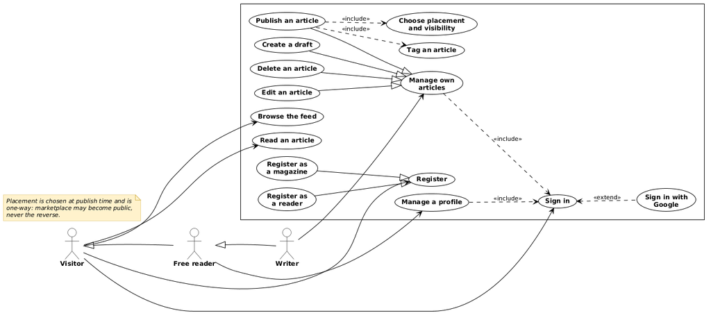

Figure 4.1 – Use case diagram, Sprint 1

**Textual description.** Table 4.2 details the central use case of the sprint.

**Table 4.2 – Textual description of “Publish an article”**

[output not shown]

### 4.1.3 Design

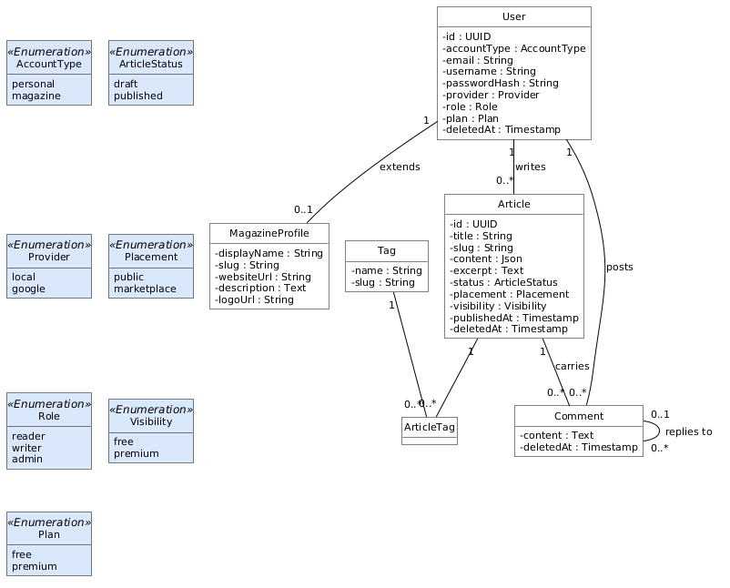

Figure 4.2 – Class diagram, Sprint 1

**Sequence diagram — sign in.** Figure 4.3 shows signing in and the silent refresh that keeps a session alive. Sign-in is rate-limited per address — ten attempts a minute, five for registration, against sixty for other routes — and answers 429 before the account is even read. On success the system issues a 15-minute access token and a 7-day refresh token; when a later request meets an expired access token, the client refreshes it, rewrites both the client store and the cookie the route proxy reads, and retries the original request transparently.

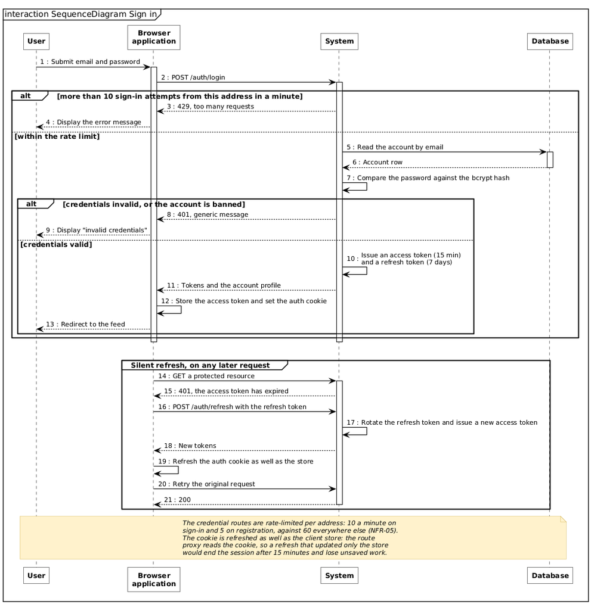

Figure 4.3 – Sequence diagram: sign in and silent refresh

**The ledger invariant harness.** Money-like data appears from Sprint 5 onwards, but its correctness rule is set here: every denormalised balance — a magazine’s credit balance, a writer’s earnings — must equal the sum of its ledger rows. Three invariants encode that rule and are asserted after every test that moves credits. The harness is tested by sabotage: fixtures build a coherent purchase, then corrupt one column at a time and check that the right invariant fails.

## 4.2 Sprint 2 — Editor, AI assistance and event capture

### 4.2.1 Sprint goal and backlog

**Goal:** a writer drafts in a rich-text editor with automatic saving and images; a premium writer converses with an AI assistant and applies inline AI actions to a selection, within a daily token allowance; every article page records reading events.

**Table 4.3 – Sprint 2 backlog**

| ID | User story | Priority | Points |
| --- | --- | --- | --- |
| US-06 | Write in a rich editor so that structure and emphasis survive publication | Must | 8 |
| US-07 | Have my draft saved as I type so that I never lose work | Must | 3 |
| US-08 | Paste or drag an image into the article so that illustrating is not a detour | Must | 5 |
| US-09 | Set a cover image so that my article looks deliberate in the feed | Should | 3 |
| US-13 | See word count and reading time so that I can judge length as I write | Could | 1 |
| US-14 | Ask an assistant that has read my published work so that suggestions sound like me | Must | 13 |
| US-15 | Reformulate, shorten, expand, simplify or improve a selection so that editing is one click | Must | 8 |
| US-16 | Insert an answer into my document so that I do not copy by hand | Must | 2 |
| US-18 | See my remaining allowance so that I can pace my usage | Must | 2 |
|  | **9 stories** |  | **45** |

### 4.2.2 Analysis

Figure 4.10 gives the use cases of Sprint 2. Writing in the editor specialises into formatting, inserting an image and setting a cover image, and includes saving the draft automatically. Using the assistant specialises into chatting and applying an inline action, and includes consuming the daily allowance; inserting the answer into the document extends the chat. Reading an article includes recording reading events.

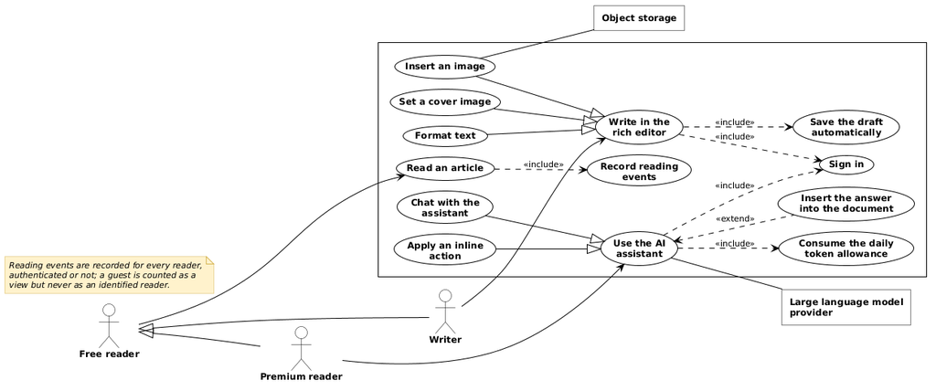

Figure 4.10 – Use case diagram, Sprint 2

### 4.2.3 Design

**Class diagram.** Figure 4.11 adds the classes of Sprint 2: each AI call is logged as an `AiInteraction` with its action type, tokens used and model; reading is recorded as `AnalyticsEvent` rows (view, scroll, time on page, like, comment, repost); and the user carries the remaining daily token allowance and the time of its last reset. The `voice_transcribe` action type is reserved in the enumeration and used from Sprint 8.

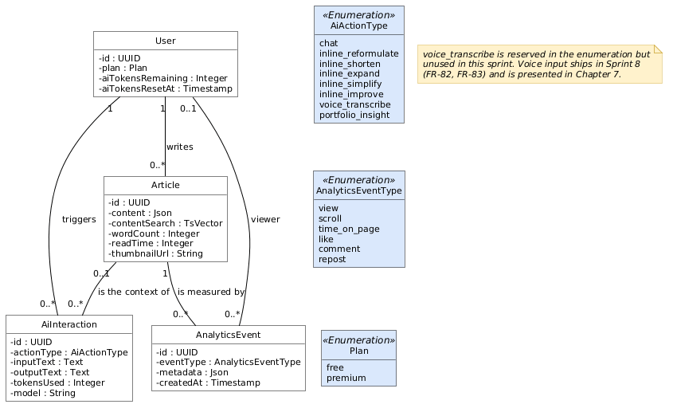

Figure 4.11 – Class diagram, Sprint 2

**Sequence diagram — inline AI action.** Figure 4.12 shows an inline action on a selection. The editor captures the selected range once, before anything is streamed, so that a click elsewhere cannot move it. The system checks the daily allowance and refuses with 403 and a plan-aware notice when it is exhausted; otherwise it builds the prompt from the action, the selection and the surrounding article, streams the suggestion to the editor as it is generated, and records the interaction and its cost. The allowance is checked once, before the call: a reply may cost more than what remained, and the balance then stops at zero.

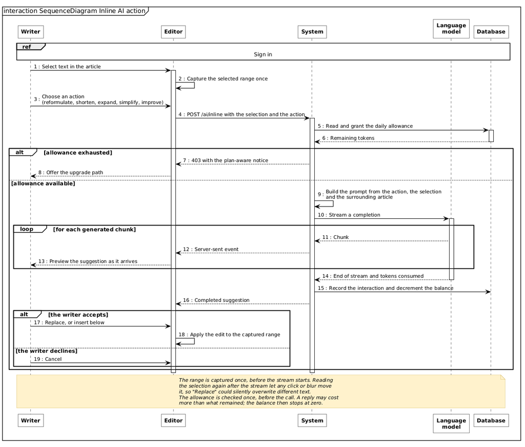

Figure 4.12 – Sequence diagram: inline AI action

**Event capture.** The article page observes scroll depth and engaged time and sends batched events — every ten events, every five seconds, or when the page is left — to `POST /analytics/events`. The server, not the client, attaches the reader’s identity from the access token, the country and the device. Capture starts in this sprint so that real reading data accumulates before the dashboards of Release 2 aggregate it.

## Conclusion

Release 1 delivered the foundation: accounts and authentication with rate limiting and a silent refresh, article management with placement and visibility, a rich-text editor, the first AI assistant with inline actions under a daily allowance, and the capture of reading events. Release 2 builds the social layer and the analytics on top of it.

# Chapter 5 — Release 2: social interactions, analytics and AI

## Introduction

The second release turns a publishing tool into a platform. Sprint 3 adds the social layer — likes, threaded comments, reposts, follows, reports — with live notifications, and aggregates the reading events captured since Release 1 into the metrics behind the writer’s dashboards and the magazine’s evaluation report. Sprint 4 adds the platform’s retrieval layer: published articles are embedded, the assistant answers from the writer’s own passages and voice profile, magazines can request AI portfolio insights, and search combines keywords with meaning.

## 5.1 Sprint 3 — Social interactions, notifications and analytics

### 5.1.1 Sprint goal and backlog

**Goal:** readers interact with articles and writers, and the author is told live; writers see how their articles are read; subscribed magazines browse eligible writers and read an evaluation report built on audience, content and quality metrics.

**Table 5.1 – Sprint 3 backlog**

| ID | User story | Priority | Points |
| --- | --- | --- | --- |
| US-24 | Like an article so that I can signal quality | Must | 2 |
| US-25 | Comment and reply in a thread so that discussion has structure | Must | 5 |
| US-26 | Follow a writer so that I keep up with them | Should | 3 |
| US-27 | Repost an article so that my followers see it | Could | 2 |
| US-28 | Be told the moment someone reacts to my work, without reloading | Must | 5 |
| US-29 | Review notifications I missed so that nothing is lost between sessions | Must | 3 |
| US-30 | See how many people read an article and how far they got so that I can write better | Must | 8 |
| US-31 | Rank my articles by performance so that I learn what works | Should | 3 |
| US-32 | Evaluate a writer on audience, content and quality so that I can commission with evidence | Must | 13 |
|  | **9 stories** |  | **44** |

### 5.1.2 Analysis

Figure 5.1 gives the use cases of Sprint 3. Interacting with an article specialises into liking, commenting, replying, reposting, following and reporting, and includes notifying the recipient. On a marketplace listing, liking, commenting and reposting are refused while saving stays available, because a listing is a private commercial offer rather than a publication. Viewing article analytics and reading a writer evaluation both include the aggregation of raw events into metrics — a scheduled job rather than a user action, drawn because no metric exists without it.

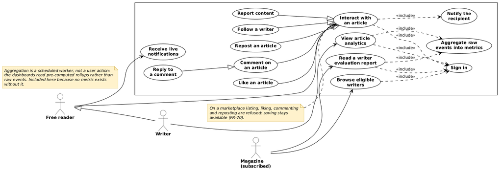

Figure 5.1 – Use case diagram, Sprint 3

### 5.1.3 Design

**Class diagram.** Figure 5.2 adds likes, comments, reposts, follows and notifications, and the four rollup tables: `ArticleMetrics` per article, and `WriterAudienceMetrics`, `WriterContentMetrics` and `WriterQualityMetrics` per writer.

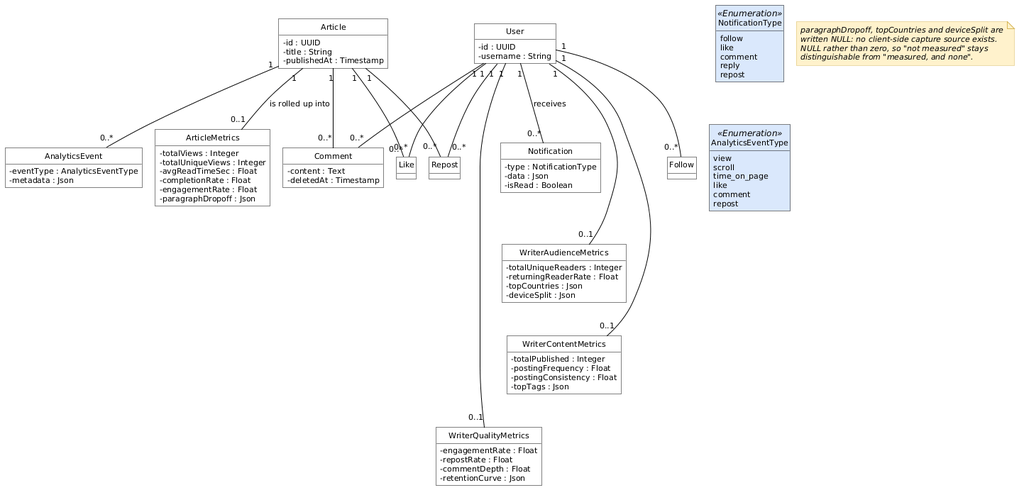

Figure 5.2 – Class diagram, Sprint 3

**Sequence diagram — from reading events to metrics.** Figure 5.3 follows a reading event to the dashboard. The browser batches events; the API takes the reader’s identity from the access token when one is sent — never from the request body — and attaches the country and device server-side before appending the event. Every five minutes the worker reads only the events since the last run and upserts the per-article metrics (views, unique views, reading time, completion and engagement); just after, it computes the three per-writer rollups and rechecks marketplace eligibility. Dashboards read the rollups, never the raw events, so they stay fast as the event log grows.

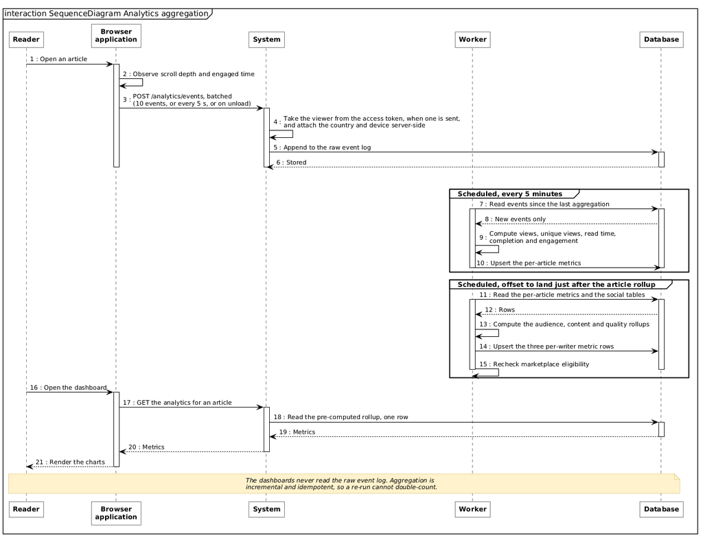

Figure 5.3 – Sequence diagram: analytics aggregation

**Table 5.2 – Main metrics of the evaluation report**

| Panel | Metric | Definition |
| --- | --- | --- |
| Audience | Unique readers | distinct identified readers across the writer’s articles |
| Audience | Returning-reader rate | share of readers who read two or more of the writer’s articles |
| Content | Posting frequency and consistency | articles per week; variation of the intervals between publications |
| Content | Topics | distribution of the writer’s articles over tags |
| Quality | Engagement rate | share of views that read past 75% of the article |
| Quality | Completion rate | share of views that reach the end |
| Quality | Repost rate, comment depth | reposts per view; replies per comment |
| Quality | Retention curve | share of readers still reading at each quarter of the article |

**Sequence diagram — live notifications.** Figure 5.4 shows how a notification reaches its recipient. The client keeps a server-sent-events stream open; when a reader likes an article, the like and the notification row are written first, and only after the commit is the event pushed to the recipient’s open streams. If the connection drops, the client reconnects with the identifier of the last event received and the server replays what was missed. Delivery is best-effort; the database is the record.

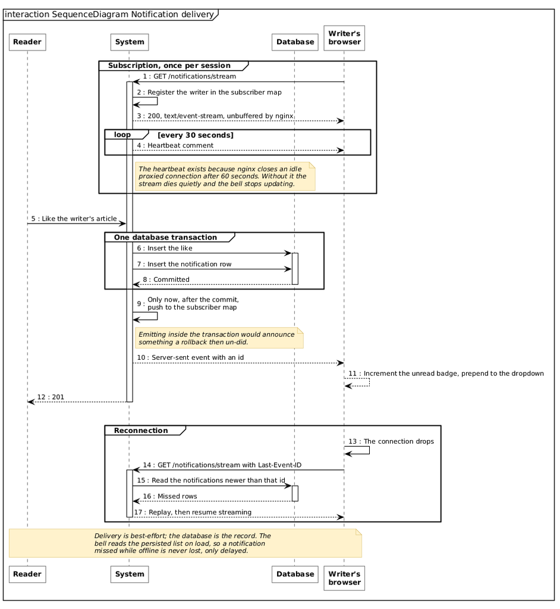

Figure 5.4 – Sequence diagram: live notification delivery

## 5.2 Sprint 4 — Retrieval, portfolio insights and hybrid search

### 5.2.1 Sprint goal and backlog

**Goal:** published articles become a retrievable corpus; the assistant answers from the writer’s own passages and shows them; each writer gets an automatically extracted voice profile; magazines request AI portfolio insights; search finds articles by meaning as well as by keyword.

**Table 5.3 – Sprint 4 backlog**

| ID | User story | Priority | Points |
| --- | --- | --- | --- |
| US-14 | Ask an assistant that has read my published work so that suggestions sound like me | Must | 13 |
| US-17 | See which of my passages the assistant used so that I can trust the answer | Should | 5 |
| US-19 | Have my voice profile extracted from my corpus so that the assistant stays consistent when retrieval finds nothing | Should | 8 |
| US-20 | Search by keyword so that I find an article I half-remember | Must | 5 |
| US-21 | Find articles that match my meaning even when they share none of my words | Must | 8 |
| US-22 | Browse by tag so that I can follow a topic | Should | 2 |
| US-23 | Find writers, not only articles, so that I can follow a person | Should | 3 |
| US-33 | Read an AI assessment of a writer’s voice and range so that I can shortlist quickly | Must | 8 |
|  | **8 stories** |  | **52** |

### 5.2.2 Analysis

Figure 5.12 gives the use cases of Sprint 4. Searching specialises into searching by keyword and by meaning and includes merging the two result sets; using the assistant includes retrieving passages from the writer’s own corpus and showing the sources used; publishing includes embedding the article, extracting the writer’s voice profile and invalidating the insights cache; reading a writer evaluation is extended by generating portfolio insights.

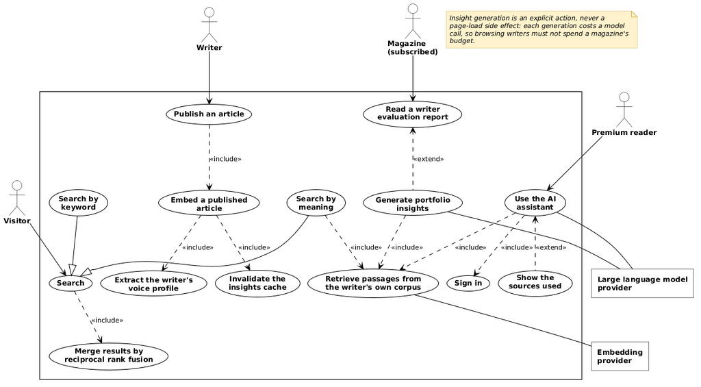

Figure 5.12 – Use case diagram, Sprint 4

### 5.2.3 Design

**Class diagram.** Figure 5.13 adds the retrieval corpus — `ArticleChunk`, a passage of a published article with its 1,536-dimension embedding — the `WriterMemory` (tone, style examples, vocabulary, topics), the cached `PortfolioInsight` and the `AiInteraction` log. Chunks exist only for published articles.

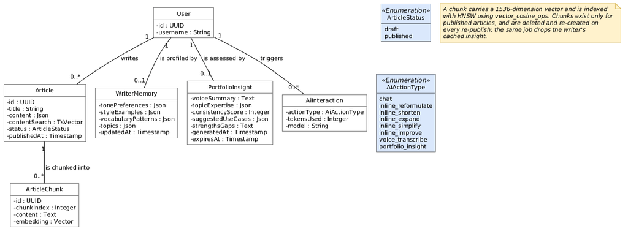

Figure 5.13 – Class diagram, Sprint 4

**Sequence diagram — what publishing sets in motion.** Figure 5.14 shows the background pipeline a publication starts. The API writes the article and enqueues an embedding job. The worker deletes the article’s previous chunks, splits it into passages of 120 to 1,200 characters — each prefixed with its nearest heading, so that a short paragraph embeds near its subject — embeds them, stores the vectors and drops the writer’s cached insights. It then chains the extraction of the writer’s voice profile: the ten most recent articles are sent to the model, which returns tone, style, vocabulary and topics as a schema-validated object.

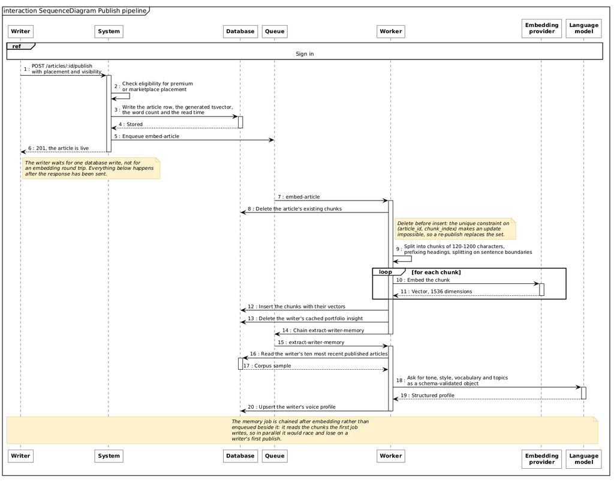

Figure 5.14 – Sequence diagram: the publishing pipeline

**Sequence diagram — a chat turn grounded in the writer’s corpus.** Figure 5.15 shows retrieval-augmented generation as delivered in this sprint. The question is embedded; the five passages of the writer’s own work closest to it by cosine similarity are retrieved, provided they score at least 0.60; the voice profile is read; the prompt is assembled from role, memory, passages and question, bounded at about 2,000 tokens; the answer is streamed, and the passages used are shown as sources. The similarity floor was measured rather than chosen: with this embedding model, on-topic passages scored 0.63–0.73 and off-topic ones 0.48–0.58, so a floor of 0.60 lets retrieval return nothing rather than five irrelevant passages.

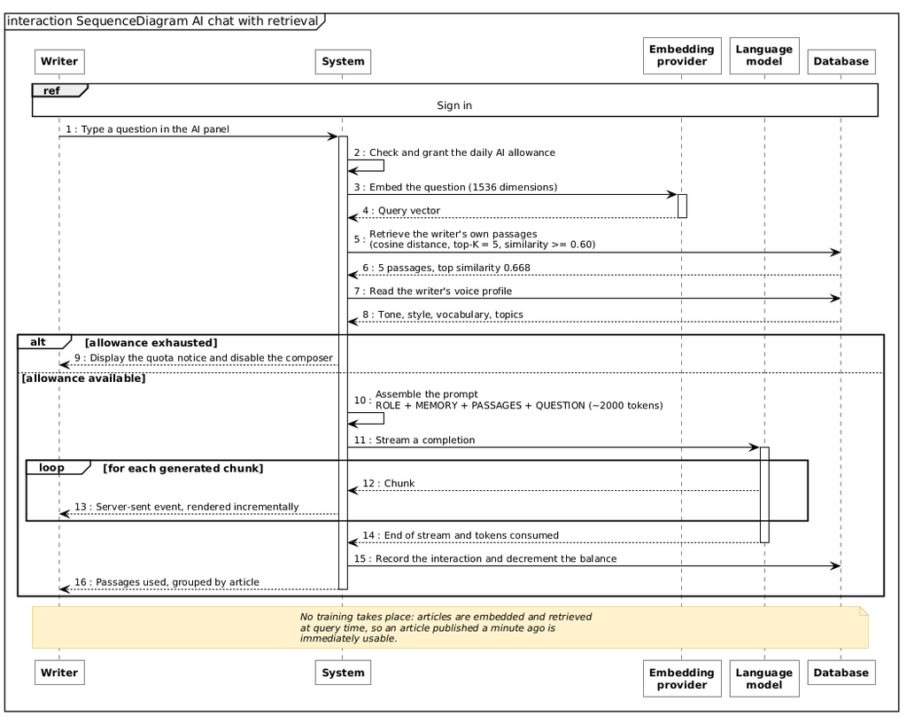

Figure 5.15 – Sequence diagram: AI chat with retrieval

**Sequence diagram — hybrid search.** Figure 5.16 shows search. The query is ranked lexically with `ts_rank` over the article’s weighted search vector, and semantically by cosine distance, keeping the best chunk per article. Because the two scores are on unrelated scales, the rankings are fused by position with reciprocal rank fusion — each article scores Σ 1/(60 + rank) — so an article that never uses the searcher’s words can still be found by meaning.

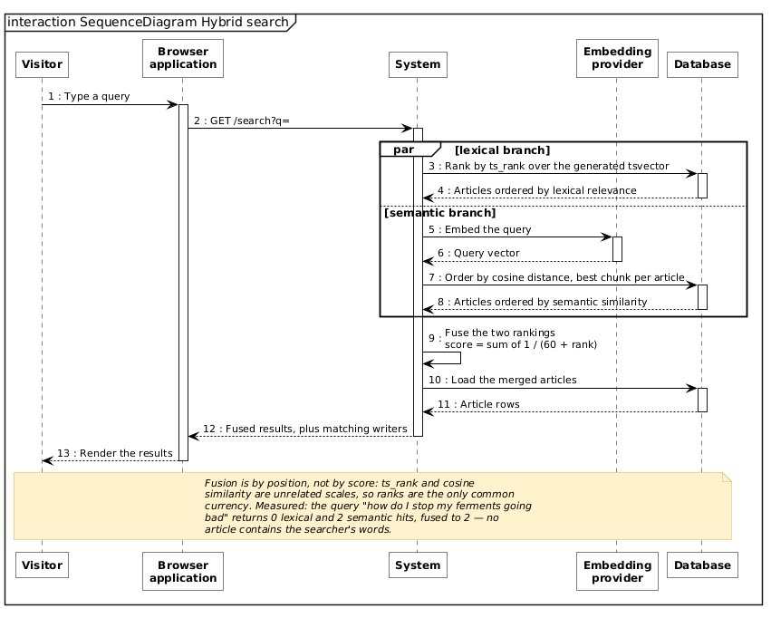

Figure 5.16 – Sequence diagram: hybrid search with reciprocal rank fusion

## Conclusion

Release 2 made Inkwell.ai social and measurable: interactions with live notifications, reading events aggregated into per-article and per-writer metrics, an evaluation report for magazines, and a retrieval layer that grounds the assistant in the writer’s own work, produces portfolio insights and powers hybrid search. Release 3 builds the marketplace those signals were designed for.

# Chapter 6 — Release 3: marketplace, testing and deployment

## Introduction

The third release delivers the reason the analytics exist: the marketplace. Sprint 5 adds the premium plan, magazine subscriptions and credits, the eligibility gate, the two-stage purchase with exclusive rights and the magazine’s own act of publishing, and the moderation console. Sprint 6 hardens the whole: the test strategy, a demonstration corpus, and a production-ready deployment with its continuous-delivery pipeline.

## 6.1 Sprint 5 — Marketplace, subscriptions, premium and moderation

### 6.1.1 Sprint goal and backlog

**Goal:** readers upgrade to premium; magazines subscribe and receive monthly credits; eligible writers list articles; magazines preview, buy and publish them under their own masthead, every credit movement recorded in a ledger; writers see their earnings; administrators moderate.

**Table 6.1 – Sprint 5 backlog**

| ID | User story | Priority | Points |
| --- | --- | --- | --- |
| US-12 | Restrict an article to premium readers so that my best work is worth a subscription | Should | 3 |
| US-34 | Upgrade to premium so that I can read everything and use the assistant | Must | 5 |
| US-35 | Subscribe as a magazine so that I can access the marketplace | Must | 8 |
| US-36 | Receive a monthly credit budget so that spending is predictable | Must | 5 |
| US-37 | Top up credits so that a good month is not capped | Should | 3 |
| US-38 | Pay 10% to read an article in full so that I can judge before buying | Must | 8 |
| US-39 | Pay the remainder to acquire republish rights so that I can publish it | Must | 8 |
| US-40 | Keep purchased articles in a library so that my acquisitions are in one place | Must | 3 |
| US-63 | Publish an article I have bought when I am ready, rather than the purchase publishing it for me, so that my masthead stays mine to decide | Must | 5 |
| US-64 | Have the articles I publish appear on my public profile under my masthead so that licensing buys me a shelf and not just a file | Must | 5 |
| US-41 | List an article for sale at my own price so that I am paid for exclusivity | Must | 5 |
| US-42 | See my earnings itemised by preview and purchase so that I trust the accounting | Must | 5 |
| US-43 | See how far I am from eligibility so that the gate feels reachable | Should | 3 |
| US-44 | Report content so that abuse has a channel | Must | 3 |
| US-45 | Work a queue of reports so that moderation is systematic | Must | 5 |
| US-46 | Remove an article or ban an author so that decisions are enforceable | Must | 3 |
| US-47 | Grant eligibility manually so that a promising writer is not held back by a counter | Must | 3 |
| US-48 | Search and filter users so that I can act on the right account | Should | 5 |
|  | **18 stories** |  | **85** |

### 6.1.2 Business rules

**Table 6.2 – Marketplace rules**

| Rule | Value |
| --- | --- |
| Eligibility to list or publish premium | 5,000 identified unique readers **and** 1,000 reactions (likes and comments) across the writer’s public articles, lifetime; or a manual grant by an administrator. Never revoked automatically. |
| Magazine subscription | monthly; grants 500 credits a month; unspent credits roll over |
| Preview unlock | 10% of the article’s price, credited towards the purchase |
| Full purchase | the remaining 90%; exclusive — no other magazine can preview or buy the article afterwards |
| Platform fee | 20% of each stage, rounded down; the writer receives the rest |
| Publication | a separate, deliberate act of the owning magazine: the article becomes public and free, its price is cleared and the magazine is recorded as publisher |

### 6.1.3 Analysis

**Use case diagram.** Figure 6.1 gives the use cases of Sprint 5. An unsubscribed magazine can only subscribe; a subscribed magazine browses the marketplace, purchases an article exclusively — unlocking a preview extends the purchase — tops up credits, views its library and publishes a purchased article from it. Every credit movement includes moving credits in one transaction. An eligible writer lists an article, which includes setting a price and classifying the content at publish time; the administrator reviews the report queue, grants eligibility and manages users.

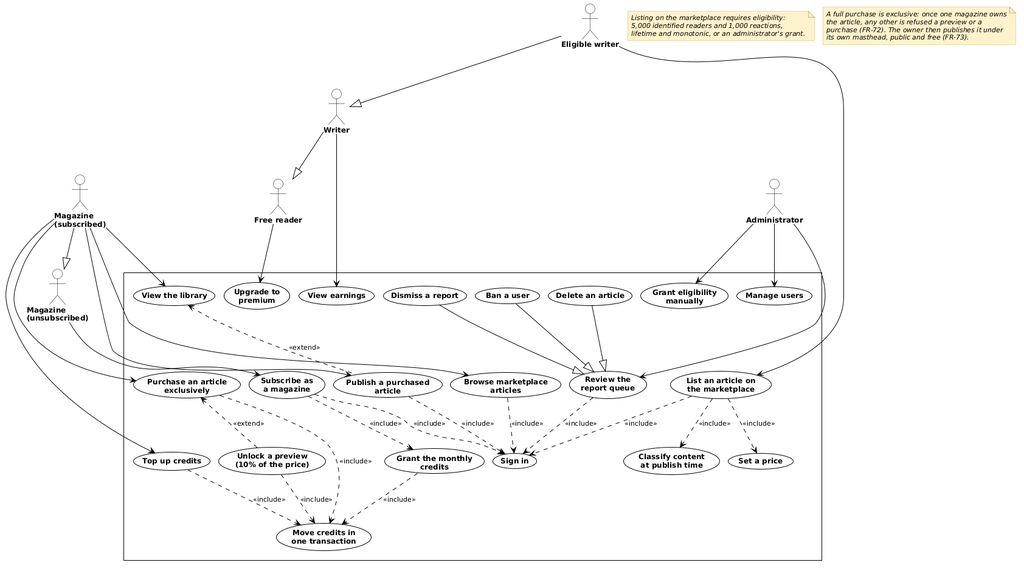

Figure 6.1 – Use case diagram, Sprint 5

### 6.1.4 Design

**Class diagram.** Figure 6.2 shows licensing and the ledger. A `Purchase` records a stage — preview unlock or full purchase — with the credits paid, the platform fee and the writer’s payout, and a full purchase links to the preview that preceded it. Each stage writes three `Transaction` rows: the magazine’s debit, the writer’s payout and the platform fee; amounts are always positive and their direction comes from the type, enforced by a constraint. `Article.publisherId` is what tells the three states of a marketplace article apart: listed (no full purchase), owned (a full purchase, not yet public) and published (public and free, with the magazine as publisher).

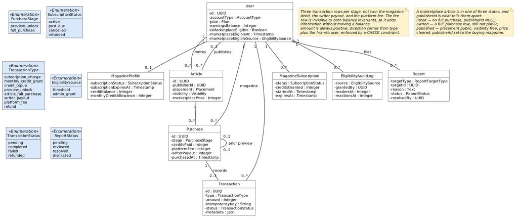

Figure 6.2 – Class diagram, Sprint 5

**Sequence diagram — the purchase.** Figure 6.3 shows the three calls of a licence. Each purchase stage opens one database transaction: it locks the article row and reads its owner, refusing with 409 if another magazine already owns it — before any arithmetic, so a refusal rolls back an empty unit of work — then locks the magazine’s credit balance, refuses with 402 when it is insufficient, debits the magazine, credits the writer, and writes the purchase and its three ledger rows. The full purchase charges only what the preview has not already paid. It leaves the article in the magazine’s library, owned and unpublished; publishing is a third call. Every request carries an idempotency key, so a retried request cannot charge twice, and the row lock stops two concurrent purchases from spending the same credits.

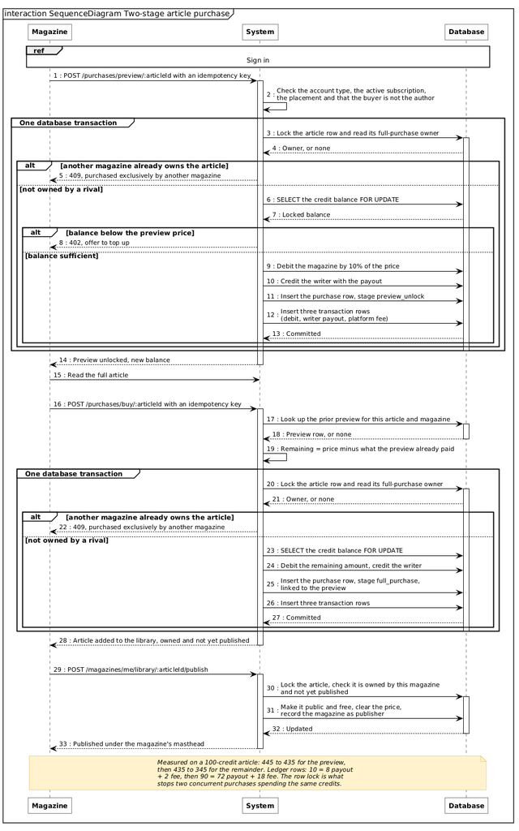

Figure 6.3 – Sequence diagram: preview, purchase and publication

**Activity diagram — the eligibility gate.** Figure 6.4 shows eligibility: after each aggregation the worker checks writers above both thresholds who are not yet eligible, marks them eligible and writes an audit-log entry with the metric snapshot; an administrator can grant eligibility directly, with the same audit trail. Comment likes and reposts are deliberately not counted as reactions, so that other people’s activity cannot move a writer’s threshold.

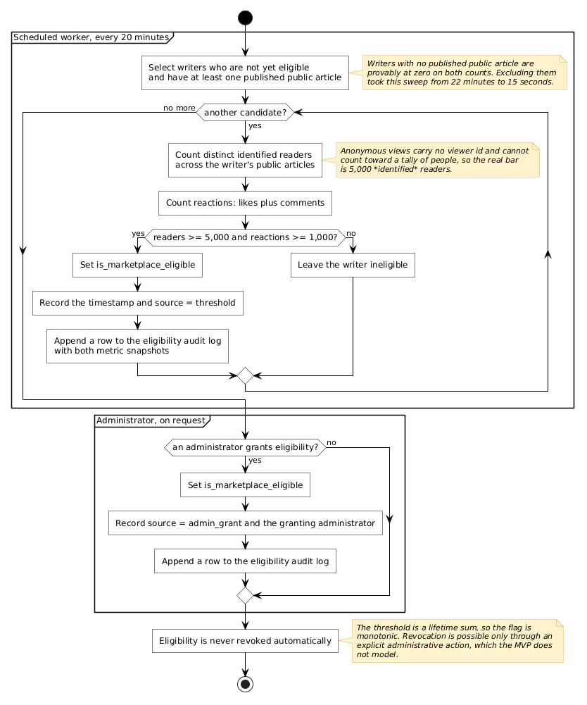

Figure 6.4 – Activity diagram: the marketplace eligibility gate

**Sequence diagram — moderation.** Figure 6.5 shows the two sources of reports. At publish time a classifier model reviews the article; a flag files a pending report with no reporter but never blocks publication. Readers report articles, users or comments. The administrator works the queue: dismiss the report, remove the article or ban the author — a ban taking effect at the next authentication.

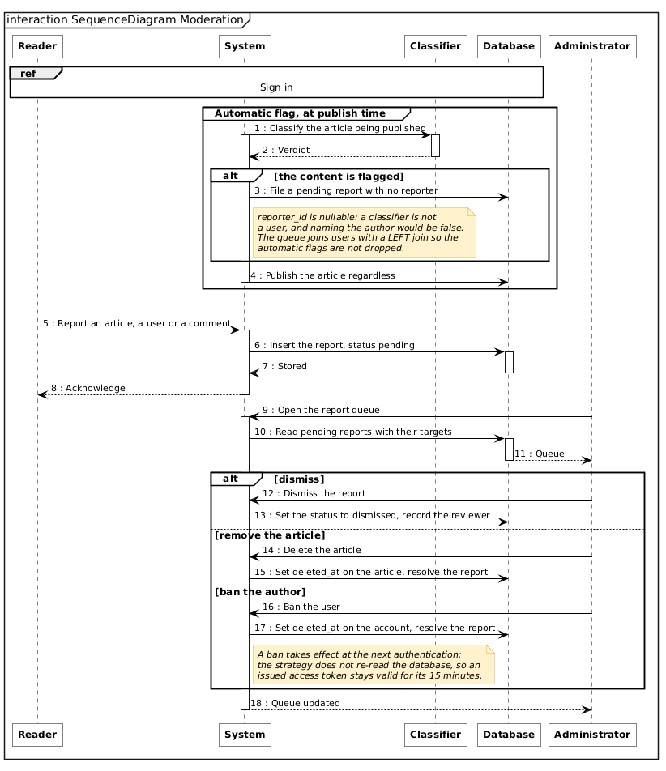

Figure 6.5 – Sequence diagram: reporting and moderation

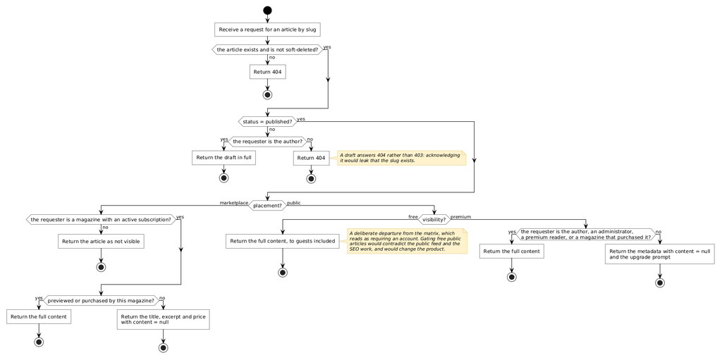

Figure 6.6 – Activity diagram: the article access decision

**State diagram — the article lifecycle.** Figure 6.7 shows the states an article goes through and the only transitions the API permits. A draft is published as free, premium or listed on the marketplace. A listed article can be withdrawn to public — never the reverse, because an article the public has read has no exclusivity left to sell — or deleted, as long as no magazine owns it. Its first full purchase makes it *owned*, after which the writer can neither withdraw nor delete it; the magazine’s publication makes it *published by a magazine*, public and free.

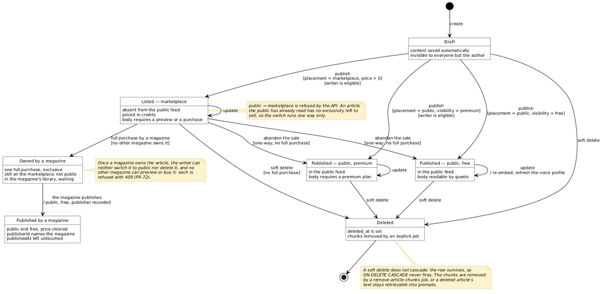

Figure 6.7 – State diagram: the article lifecycle